# Explanability Study

Michael Amodeo, Krista Mar, Mona Iwamoto

## Data Import and Prepration

### Import data

In order to appropriately capture the instances where someone did not finish the survey, whether by clicking through to the final page or by stopping midway, I had to export from Qualtrics in a different format that allows us to see what was viewed and what was not. That also changed some other fields, particularly the multiple choice, multiple selection questions.

```r
#Import all data
all_content = readLines("Explainability_Study_legacy_export.csv")

#Delete second and third rows of not useful information
skip_second = all_content[-c(2,3)]

#Create table and data.table
d <-read.csv(textConnection(skip_second), header = TRUE, stringsAsFactors = FALSE)
d <- data.table(d)

# Create new data table without fields we are not using
dt <- d[,-c('ResponseSet','IPAddress','StartDate','EndDate','RecipientLastName',
          'RecipientFirstName','RecipientEmail','ExternalDataReference','Status',
          'Q_TotalDuration','Enter.Embedded.Data.Field.Name.Here...','LocationLatitude',
          'LocationLongitude','LocationAccuracy', 'Q3.5', 'Q4.5', 'Q6.5', 'Q7.5', 'Q8.1',
          'Q9.1','Q10.1', 'Q10.3')]

# Rename variables
old_names <- colnames(dt)

##  Key to var names: tc = Twitter control group
#                     tt = Twitter treatment group
#                     rc = recidivism control group
#                     rt = recidivism treatment group

new_names <- c("ResponseID","Finished","First.Context","random","intro","tweet",
               "tControl", 'tcFair', 'tcAcc', 'tcSat', 'tcUseful', 'tcClear',
               'tcMeaningful', 'tcReqInfo', 'tcOther1', 'tcOther2', 'tcOther3', 'tcOther4',
               "tTreat", 'ttFair', 'ttAcc', 'ttSat', 'ttUseful', 'ttClear',
               'ttMeaningful', 'ttReqInfo', 'ttOther1', 'ttOther2', 'ttOther3', 'ttOther4',
               'recidivism',
               'rControl', 'rcFair', 'rcAcc', 'rcSat', 'rcUseful', 'rcClear',
               'rcMeaningful', 'rcReqInfo', 'rcOther1', 'rcOther2', 'rcOther3', 'rcOther4',
               "rTreat", 'rtFair', 'rtAcc', 'rtSat', 'rtUseful', 'rtClear',
               'rtMeaningful', 'rtReqInfo', 'rtOther1', 'rtOther2', 'rtOther3', 'rtOther4',
               'ageGroup', 'white', 'black', 'native', 'asian', 'pac_isle', 'hispanic',
               'other', 'gender', 'socMed', 'educ', 'feedback')

setnames(dt, old_names, new_names)
colnames(dt)
```

```
##  [1] "ResponseID"    "Finished"      "First.Context" "random"
##  [5] "intro"         "tweet"         "tControl"      "tcFair"
##  [9] "tcAcc"         "tcSat"         "tcUseful"      "tcClear"
## [13] "tcMeaningful"  "tcReqInfo"     "tcOther1"      "tcOther2"
## [17] "tcOther3"      "tcOther4"      "tTreat"        "ttFair"
## [21] "ttAcc"         "ttSat"         "ttUseful"      "ttClear"
## [25] "ttMeaningful"  "ttReqInfo"     "ttOther1"      "ttOther2"
## [29] "ttOther3"      "ttOther4"      "recidivism"    "rControl"
## [33] "rcFair"        "rcAcc"         "rcSat"         "rcUseful"
## [37] "rcClear"       "rcMeaningful"  "rcReqInfo"     "rcOther1"
## [41] "rcOther2"      "rcOther3"      "rcOther4"      "rTreat"
## [45] "rtFair"        "rtAcc"         "rtSat"         "rtUseful"
## [49] "rtClear"       "rtMeaningful"  "rtReqInfo"     "rtOther1"
## [53] "rtOther2"      "rtOther3"      "rtOther4"      "ageGroup"
## [57] "white"         "black"         "native"        "asian"
## [61] "pac_isle"      "hispanic"      "other"         "gender"
## [65] "socMed"        "educ"          "feedback"
```

```r
summary(dt)
```

```
##   ResponseID           Finished     First.Context          random
##  Length:641         Min.   :0.000   Length:641         Min.   :101932
##  Class :character   1st Qu.:1.000   Class :character   1st Qu.:312585
##  Mode  :character   Median :1.000   Mode  :character   Median :539727
##                     Mean   :0.908                      Mean   :539154
##                     3rd Qu.:1.000                      3rd Qu.:758124
##                     Max.   :1.000                      Max.   :999250
##                                                        NA's   :19
##      intro       tweet       tControl       tcFair          tcAcc
##  Min.   :1   Min.   :1    Min.   :1     Min.   :1.000   Min.   :1.000
##  1st Qu.:1   1st Qu.:1    1st Qu.:1     1st Qu.:2.000   1st Qu.:2.000
##  Median :1   Median :1    Median :1     Median :3.000   Median :3.000
##  Mean   :1   Mean   :1    Mean   :1     Mean   :3.197   Mean   :2.629
##  3rd Qu.:1   3rd Qu.:1    3rd Qu.:1     3rd Qu.:4.000   3rd Qu.:3.000
##  Max.   :1   Max.   :1    Max.   :1     Max.   :5.000   Max.   :5.000
##              NA's   :10   NA's   :326   NA's   :326     NA's   :326
##      tcSat          tcUseful        tcClear      tcMeaningful
##  Min.   :1.000   Min.   :1.000   Min.   :1.00   Min.   :1.000
##  1st Qu.:2.000   1st Qu.:2.000   1st Qu.:2.00   1st Qu.:2.000
##  Median :2.000   Median :3.000   Median :2.00   Median :3.000
##  Mean   :2.476   Mean   :3.035   Mean   :2.47   Mean   :3.114
##  3rd Qu.:3.000   3rd Qu.:4.000   3rd Qu.:3.00   3rd Qu.:4.000
##  Max.   :5.000   Max.   :5.000   Max.   :5.00   Max.   :5.000
##  NA's   :326     NA's   :326     NA's   :326    NA's   :326
##    tcReqInfo      tcOther1      tcOther2      tcOther3
##  Min.   :1     Min.   :1     Min.   :1     Min.   :1
##  1st Qu.:1     1st Qu.:1     1st Qu.:1     1st Qu.:1
##  Median :1     Median :1     Median :1     Median :1
##  Mean   :1     Mean   :1     Mean   :1     Mean   :1
##  3rd Qu.:1     3rd Qu.:1     3rd Qu.:1     3rd Qu.:1
##  Max.   :1     Max.   :1     Max.   :1     Max.   :1
##  NA's   :557   NA's   :468   NA's   :496   NA's   :632
##    tcOther4             tTreat        ttFair          ttAcc
##  Length:641         Min.   :1     Min.   :1.000   Min.   :1.000
##  Class :character   1st Qu.:1     1st Qu.:2.000   1st Qu.:2.000
##  Mode  :character   Median :1     Median :2.000   Median :2.000
##                     Mean   :1     Mean   :2.561   Mean   :2.471
##                     3rd Qu.:1     3rd Qu.:3.000   3rd Qu.:3.000
##                     Max.   :1     Max.   :5.000   Max.   :5.000
##                     NA's   :329   NA's   :329     NA's   :329
```

[output cut: 73 more lines]

```
##  Min.   :1     Min.   :1     Min.   :1     Min.   :1     Min.   :1
##  1st Qu.:1     1st Qu.:1     1st Qu.:1     1st Qu.:1     1st Qu.:1
##  Median :1     Median :1     Median :1     Median :1     Median :1
##  Mean   :1     Mean   :1     Mean   :1     Mean   :1     Mean   :1
##  3rd Qu.:1     3rd Qu.:1     3rd Qu.:1     3rd Qu.:1     3rd Qu.:1
##  Max.   :1     Max.   :1     Max.   :1     Max.   :1     Max.   :1
##  NA's   :627   NA's   :507   NA's   :640   NA's   :611   NA's   :636
##      gender          socMed           educ        feedback
##  Min.   :1.000   Min.   :1.000   Min.   :11.0   Length:641
##  1st Qu.:1.000   1st Qu.:1.000   1st Qu.:13.0   Class :character
##  Median :1.000   Median :1.000   Median :15.0   Mode  :character
##  Mean   :1.352   Mean   :1.322   Mean   :14.3
##  3rd Qu.:2.000   3rd Qu.:1.000   3rd Qu.:15.0
##  Max.   :3.000   Max.   :5.000   Max.   :17.0
##  NA's   :21      NA's   :19      NA's   :19
```

### Data Cleanup

```r
# Most Qualtrics questions were set so the extreme positive value was the first choice (1)
# Function to flip the scale to show more positive as larger number
flip <- function(originalScale) {
  x <- originalScale - 3        #  3 is median
  return(3 - x)
}

# For an unknown reason, question 7.2 Fairness for Recidivism Treatment
# the values were offset by 24.  This was cross-checked with the text-based responses.

dt$rtFair <- dt$rtFair - 24      # Qualtrics weirdness

# For the Twitter fairness questions, the Qualtrics survey
# responses were reversed in two instances. All others
# are reversed using the flip function below

# Organize scales so larger values correlate to more fair, more accurate, etc.
dt[, tcAcc        := flip(dt[, tcAcc])]
```

```
##             ResponseID Finished First.Context random intro tweet tControl
##   1: R_sokjh5LnTh47Oi5        1    Recidivism 298027     1     1        1
##   2: R_1Nqxa3Mf0DWHrR4        1       Twitter 961809     1     1       NA
##   3: R_2OIODjmFxH3h5Cg        1    Recidivism 617169     1     1       NA
##   4: R_29nXMn5A6yq1ny9        1       Twitter 810593     1     1        1
##   5: R_24uPaD68fpK7iCM        1       Twitter 708955     1     1       NA
##  ---
## 637: R_1Lp4arXwXpI04Lq        0       Twitter 566639     1     1        1
## 638: R_2UbwResocVbp6aA        0       Twitter     NA     1     1       NA
## 639: R_ZJmNWyfdlFJsjD3        0    Recidivism     NA     1    NA       NA
## 640: R_1feeh2b1o3jXPIO        0    Recidivism 538771     1     1       NA
## 641: R_2bOYMwQgQEbjlFL        0    Recidivism 287258     1     1        1
##      tcFair tcAcc tcSat tcUseful tcClear tcMeaningful tcReqInfo tcOther1
##   1:      5     2     5        4       4            4        NA        1
##   2:     NA    NA    NA       NA      NA           NA        NA       NA
```

[output cut: 93 more lines]

```r
dt[, tcSat        := flip(dt[, tcSat])]
```

```
##             ResponseID Finished First.Context random intro tweet tControl
##   1: R_sokjh5LnTh47Oi5        1    Recidivism 298027     1     1        1
##   2: R_1Nqxa3Mf0DWHrR4        1       Twitter 961809     1     1       NA
##   3: R_2OIODjmFxH3h5Cg        1    Recidivism 617169     1     1       NA
##   4: R_29nXMn5A6yq1ny9        1       Twitter 810593     1     1        1
##   5: R_24uPaD68fpK7iCM        1       Twitter 708955     1     1       NA
##  ---
## 637: R_1Lp4arXwXpI04Lq        0       Twitter 566639     1     1        1
## 638: R_2UbwResocVbp6aA        0       Twitter     NA     1     1       NA
## 639: R_ZJmNWyfdlFJsjD3        0    Recidivism     NA     1    NA       NA
## 640: R_1feeh2b1o3jXPIO        0    Recidivism 538771     1     1       NA
## 641: R_2bOYMwQgQEbjlFL        0    Recidivism 287258     1     1        1
##      tcFair tcAcc tcSat tcUseful tcClear tcMeaningful tcReqInfo tcOther1
##   1:      5     2     1        4       4            4        NA        1
##   2:     NA    NA    NA       NA      NA           NA        NA       NA
```

[output cut: 93 more lines]

```r
dt[, tcUseful     := flip(dt[, tcUseful])]
```

```
##             ResponseID Finished First.Context random intro tweet tControl
##   1: R_sokjh5LnTh47Oi5        1    Recidivism 298027     1     1        1
##   2: R_1Nqxa3Mf0DWHrR4        1       Twitter 961809     1     1       NA
##   3: R_2OIODjmFxH3h5Cg        1    Recidivism 617169     1     1       NA
##   4: R_29nXMn5A6yq1ny9        1       Twitter 810593     1     1        1
##   5: R_24uPaD68fpK7iCM        1       Twitter 708955     1     1       NA
##  ---
## 637: R_1Lp4arXwXpI04Lq        0       Twitter 566639     1     1        1
## 638: R_2UbwResocVbp6aA        0       Twitter     NA     1     1       NA
## 639: R_ZJmNWyfdlFJsjD3        0    Recidivism     NA     1    NA       NA
## 640: R_1feeh2b1o3jXPIO        0    Recidivism 538771     1     1       NA
## 641: R_2bOYMwQgQEbjlFL        0    Recidivism 287258     1     1        1
##      tcFair tcAcc tcSat tcUseful tcClear tcMeaningful tcReqInfo tcOther1
##   1:      5     2     1        2       4            4        NA        1
##   2:     NA    NA    NA       NA      NA           NA        NA       NA
```

[output cut: 93 more lines]

```r
dt[, tcClear      := flip(dt[, tcClear])]
```

```
##             ResponseID Finished First.Context random intro tweet tControl
##   1: R_sokjh5LnTh47Oi5        1    Recidivism 298027     1     1        1
##   2: R_1Nqxa3Mf0DWHrR4        1       Twitter 961809     1     1       NA
##   3: R_2OIODjmFxH3h5Cg        1    Recidivism 617169     1     1       NA
##   4: R_29nXMn5A6yq1ny9        1       Twitter 810593     1     1        1
##   5: R_24uPaD68fpK7iCM        1       Twitter 708955     1     1       NA
##  ---
## 637: R_1Lp4arXwXpI04Lq        0       Twitter 566639     1     1        1
## 638: R_2UbwResocVbp6aA        0       Twitter     NA     1     1       NA
## 639: R_ZJmNWyfdlFJsjD3        0    Recidivism     NA     1    NA       NA
## 640: R_1feeh2b1o3jXPIO        0    Recidivism 538771     1     1       NA
## 641: R_2bOYMwQgQEbjlFL        0    Recidivism 287258     1     1        1
##      tcFair tcAcc tcSat tcUseful tcClear tcMeaningful tcReqInfo tcOther1
##   1:      5     2     1        2       2            4        NA        1
##   2:     NA    NA    NA       NA      NA           NA        NA       NA
```

[output cut: 93 more lines]

```r
dt[, tcMeaningful := flip(dt[, tcMeaningful])]
```

```
##             ResponseID Finished First.Context random intro tweet tControl
##   1: R_sokjh5LnTh47Oi5        1    Recidivism 298027     1     1        1
##   2: R_1Nqxa3Mf0DWHrR4        1       Twitter 961809     1     1       NA
##   3: R_2OIODjmFxH3h5Cg        1    Recidivism 617169     1     1       NA
##   4: R_29nXMn5A6yq1ny9        1       Twitter 810593     1     1        1
##   5: R_24uPaD68fpK7iCM        1       Twitter 708955     1     1       NA
##  ---
## 637: R_1Lp4arXwXpI04Lq        0       Twitter 566639     1     1        1
## 638: R_2UbwResocVbp6aA        0       Twitter     NA     1     1       NA
## 639: R_ZJmNWyfdlFJsjD3        0    Recidivism     NA     1    NA       NA
## 640: R_1feeh2b1o3jXPIO        0    Recidivism 538771     1     1       NA
## 641: R_2bOYMwQgQEbjlFL        0    Recidivism 287258     1     1        1
##      tcFair tcAcc tcSat tcUseful tcClear tcMeaningful tcReqInfo tcOther1
##   1:      5     2     1        2       2            2        NA        1
##   2:     NA    NA    NA       NA      NA           NA        NA       NA
```

[output cut: 93 more lines]

```r
dt[, ttFair       := flip(dt[, ttFair])]
```

```
##             ResponseID Finished First.Context random intro tweet tControl
##   1: R_sokjh5LnTh47Oi5        1    Recidivism 298027     1     1        1
##   2: R_1Nqxa3Mf0DWHrR4        1       Twitter 961809     1     1       NA
##   3: R_2OIODjmFxH3h5Cg        1    Recidivism 617169     1     1       NA
##   4: R_29nXMn5A6yq1ny9        1       Twitter 810593     1     1        1
##   5: R_24uPaD68fpK7iCM        1       Twitter 708955     1     1       NA
##  ---
## 637: R_1Lp4arXwXpI04Lq        0       Twitter 566639     1     1        1
## 638: R_2UbwResocVbp6aA        0       Twitter     NA     1     1       NA
## 639: R_ZJmNWyfdlFJsjD3        0    Recidivism     NA     1    NA       NA
## 640: R_1feeh2b1o3jXPIO        0    Recidivism 538771     1     1       NA
## 641: R_2bOYMwQgQEbjlFL        0    Recidivism 287258     1     1        1
##      tcFair tcAcc tcSat tcUseful tcClear tcMeaningful tcReqInfo tcOther1
##   1:      5     2     1        2       2            2        NA        1
##   2:     NA    NA    NA       NA      NA           NA        NA       NA
```

[output cut: 93 more lines]

```r
dt[, ttAcc        := flip(dt[, ttAcc])]
```

```
##             ResponseID Finished First.Context random intro tweet tControl
##   1: R_sokjh5LnTh47Oi5        1    Recidivism 298027     1     1        1
##   2: R_1Nqxa3Mf0DWHrR4        1       Twitter 961809     1     1       NA
##   3: R_2OIODjmFxH3h5Cg        1    Recidivism 617169     1     1       NA
##   4: R_29nXMn5A6yq1ny9        1       Twitter 810593     1     1        1
##   5: R_24uPaD68fpK7iCM        1       Twitter 708955     1     1       NA
##  ---
## 637: R_1Lp4arXwXpI04Lq        0       Twitter 566639     1     1        1
## 638: R_2UbwResocVbp6aA        0       Twitter     NA     1     1       NA
## 639: R_ZJmNWyfdlFJsjD3        0    Recidivism     NA     1    NA       NA
## 640: R_1feeh2b1o3jXPIO        0    Recidivism 538771     1     1       NA
## 641: R_2bOYMwQgQEbjlFL        0    Recidivism 287258     1     1        1
##      tcFair tcAcc tcSat tcUseful tcClear tcMeaningful tcReqInfo tcOther1
##   1:      5     2     1        2       2            2        NA        1
##   2:     NA    NA    NA       NA      NA           NA        NA       NA
```

[output cut: 93 more lines]

```r
dt[, ttSat        := flip(dt[, ttSat])]
```

```
##             ResponseID Finished First.Context random intro tweet tControl
##   1: R_sokjh5LnTh47Oi5        1    Recidivism 298027     1     1        1
##   2: R_1Nqxa3Mf0DWHrR4        1       Twitter 961809     1     1       NA
##   3: R_2OIODjmFxH3h5Cg        1    Recidivism 617169     1     1       NA
##   4: R_29nXMn5A6yq1ny9        1       Twitter 810593     1     1        1
##   5: R_24uPaD68fpK7iCM        1       Twitter 708955     1     1       NA
##  ---
## 637: R_1Lp4arXwXpI04Lq        0       Twitter 566639     1     1        1
## 638: R_2UbwResocVbp6aA        0       Twitter     NA     1     1       NA
## 639: R_ZJmNWyfdlFJsjD3        0    Recidivism     NA     1    NA       NA
## 640: R_1feeh2b1o3jXPIO        0    Recidivism 538771     1     1       NA
## 641: R_2bOYMwQgQEbjlFL        0    Recidivism 287258     1     1        1
##      tcFair tcAcc tcSat tcUseful tcClear tcMeaningful tcReqInfo tcOther1
##   1:      5     2     1        2       2            2        NA        1
##   2:     NA    NA    NA       NA      NA           NA        NA       NA
```

[output cut: 93 more lines]

```r
dt[, ttUseful     := flip(dt[, ttUseful])]
```

```
##             ResponseID Finished First.Context random intro tweet tControl
##   1: R_sokjh5LnTh47Oi5        1    Recidivism 298027     1     1        1
##   2: R_1Nqxa3Mf0DWHrR4        1       Twitter 961809     1     1       NA
##   3: R_2OIODjmFxH3h5Cg        1    Recidivism 617169     1     1       NA
##   4: R_29nXMn5A6yq1ny9        1       Twitter 810593     1     1        1
##   5: R_24uPaD68fpK7iCM        1       Twitter 708955     1     1       NA
##  ---
## 637: R_1Lp4arXwXpI04Lq        0       Twitter 566639     1     1        1
## 638: R_2UbwResocVbp6aA        0       Twitter     NA     1     1       NA
## 639: R_ZJmNWyfdlFJsjD3        0    Recidivism     NA     1    NA       NA
## 640: R_1feeh2b1o3jXPIO        0    Recidivism 538771     1     1       NA
## 641: R_2bOYMwQgQEbjlFL        0    Recidivism 287258     1     1        1
##      tcFair tcAcc tcSat tcUseful tcClear tcMeaningful tcReqInfo tcOther1
##   1:      5     2     1        2       2            2        NA        1
##   2:     NA    NA    NA       NA      NA           NA        NA       NA
```

[output cut: 93 more lines]

```r
dt[, ttClear      := flip(dt[, ttClear])]
```

```
##             ResponseID Finished First.Context random intro tweet tControl
##   1: R_sokjh5LnTh47Oi5        1    Recidivism 298027     1     1        1
##   2: R_1Nqxa3Mf0DWHrR4        1       Twitter 961809     1     1       NA
##   3: R_2OIODjmFxH3h5Cg        1    Recidivism 617169     1     1       NA
##   4: R_29nXMn5A6yq1ny9        1       Twitter 810593     1     1        1
##   5: R_24uPaD68fpK7iCM        1       Twitter 708955     1     1       NA
##  ---
## 637: R_1Lp4arXwXpI04Lq        0       Twitter 566639     1     1        1
## 638: R_2UbwResocVbp6aA        0       Twitter     NA     1     1       NA
## 639: R_ZJmNWyfdlFJsjD3        0    Recidivism     NA     1    NA       NA
## 640: R_1feeh2b1o3jXPIO        0    Recidivism 538771     1     1       NA
## 641: R_2bOYMwQgQEbjlFL        0    Recidivism 287258     1     1        1
##      tcFair tcAcc tcSat tcUseful tcClear tcMeaningful tcReqInfo tcOther1
##   1:      5     2     1        2       2            2        NA        1
##   2:     NA    NA    NA       NA      NA           NA        NA       NA
```

[output cut: 93 more lines]

```r
dt[, ttMeaningful := flip(dt[, ttMeaningful])]
```

```
##             ResponseID Finished First.Context random intro tweet tControl
##   1: R_sokjh5LnTh47Oi5        1    Recidivism 298027     1     1        1
##   2: R_1Nqxa3Mf0DWHrR4        1       Twitter 961809     1     1       NA
##   3: R_2OIODjmFxH3h5Cg        1    Recidivism 617169     1     1       NA
##   4: R_29nXMn5A6yq1ny9        1       Twitter 810593     1     1        1
##   5: R_24uPaD68fpK7iCM        1       Twitter 708955     1     1       NA
##  ---
## 637: R_1Lp4arXwXpI04Lq        0       Twitter 566639     1     1        1
## 638: R_2UbwResocVbp6aA        0       Twitter     NA     1     1       NA
## 639: R_ZJmNWyfdlFJsjD3        0    Recidivism     NA     1    NA       NA
## 640: R_1feeh2b1o3jXPIO        0    Recidivism 538771     1     1       NA
## 641: R_2bOYMwQgQEbjlFL        0    Recidivism 287258     1     1        1
##      tcFair tcAcc tcSat tcUseful tcClear tcMeaningful tcReqInfo tcOther1
##   1:      5     2     1        2       2            2        NA        1
##   2:     NA    NA    NA       NA      NA           NA        NA       NA
```

[output cut: 93 more lines]

```r
dt[, rcAcc        := flip(dt[, rcAcc])]
```

```
##             ResponseID Finished First.Context random intro tweet tControl
##   1: R_sokjh5LnTh47Oi5        1    Recidivism 298027     1     1        1
##   2: R_1Nqxa3Mf0DWHrR4        1       Twitter 961809     1     1       NA
##   3: R_2OIODjmFxH3h5Cg        1    Recidivism 617169     1     1       NA
##   4: R_29nXMn5A6yq1ny9        1       Twitter 810593     1     1        1
##   5: R_24uPaD68fpK7iCM        1       Twitter 708955     1     1       NA
##  ---
## 637: R_1Lp4arXwXpI04Lq        0       Twitter 566639     1     1        1
## 638: R_2UbwResocVbp6aA        0       Twitter     NA     1     1       NA
## 639: R_ZJmNWyfdlFJsjD3        0    Recidivism     NA     1    NA       NA
## 640: R_1feeh2b1o3jXPIO        0    Recidivism 538771     1     1       NA
## 641: R_2bOYMwQgQEbjlFL        0    Recidivism 287258     1     1        1
##      tcFair tcAcc tcSat tcUseful tcClear tcMeaningful tcReqInfo tcOther1
##   1:      5     2     1        2       2            2        NA        1
##   2:     NA    NA    NA       NA      NA           NA        NA       NA
```

[output cut: 93 more lines]

```r
dt[, rcSat        := flip(dt[, rcSat])]
```

```
##             ResponseID Finished First.Context random intro tweet tControl
##   1: R_sokjh5LnTh47Oi5        1    Recidivism 298027     1     1        1
##   2: R_1Nqxa3Mf0DWHrR4        1       Twitter 961809     1     1       NA
##   3: R_2OIODjmFxH3h5Cg        1    Recidivism 617169     1     1       NA
##   4: R_29nXMn5A6yq1ny9        1       Twitter 810593     1     1        1
##   5: R_24uPaD68fpK7iCM        1       Twitter 708955     1     1       NA
##  ---
## 637: R_1Lp4arXwXpI04Lq        0       Twitter 566639     1     1        1
## 638: R_2UbwResocVbp6aA        0       Twitter     NA     1     1       NA
## 639: R_ZJmNWyfdlFJsjD3        0    Recidivism     NA     1    NA       NA
## 640: R_1feeh2b1o3jXPIO        0    Recidivism 538771     1     1       NA
## 641: R_2bOYMwQgQEbjlFL        0    Recidivism 287258     1     1        1
##      tcFair tcAcc tcSat tcUseful tcClear tcMeaningful tcReqInfo tcOther1
##   1:      5     2     1        2       2            2        NA        1
##   2:     NA    NA    NA       NA      NA           NA        NA       NA
```

[output cut: 93 more lines]

```r
dt[, rcUseful     := flip(dt[, rcUseful])]
```

```
##             ResponseID Finished First.Context random intro tweet tControl
##   1: R_sokjh5LnTh47Oi5        1    Recidivism 298027     1     1        1
##   2: R_1Nqxa3Mf0DWHrR4        1       Twitter 961809     1     1       NA
##   3: R_2OIODjmFxH3h5Cg        1    Recidivism 617169     1     1       NA
##   4: R_29nXMn5A6yq1ny9        1       Twitter 810593     1     1        1
##   5: R_24uPaD68fpK7iCM        1       Twitter 708955     1     1       NA
##  ---
## 637: R_1Lp4arXwXpI04Lq        0       Twitter 566639     1     1        1
## 638: R_2UbwResocVbp6aA        0       Twitter     NA     1     1       NA
## 639: R_ZJmNWyfdlFJsjD3        0    Recidivism     NA     1    NA       NA
## 640: R_1feeh2b1o3jXPIO        0    Recidivism 538771     1     1       NA
## 641: R_2bOYMwQgQEbjlFL        0    Recidivism 287258     1     1        1
##      tcFair tcAcc tcSat tcUseful tcClear tcMeaningful tcReqInfo tcOther1
##   1:      5     2     1        2       2            2        NA        1
##   2:     NA    NA    NA       NA      NA           NA        NA       NA
```

[output cut: 93 more lines]

```r
dt[, rcClear      := flip(dt[, rcClear])]
```

```
##             ResponseID Finished First.Context random intro tweet tControl
##   1: R_sokjh5LnTh47Oi5        1    Recidivism 298027     1     1        1
##   2: R_1Nqxa3Mf0DWHrR4        1       Twitter 961809     1     1       NA
##   3: R_2OIODjmFxH3h5Cg        1    Recidivism 617169     1     1       NA
##   4: R_29nXMn5A6yq1ny9        1       Twitter 810593     1     1        1
##   5: R_24uPaD68fpK7iCM        1       Twitter 708955     1     1       NA
##  ---
## 637: R_1Lp4arXwXpI04Lq        0       Twitter 566639     1     1        1
## 638: R_2UbwResocVbp6aA        0       Twitter     NA     1     1       NA
## 639: R_ZJmNWyfdlFJsjD3        0    Recidivism     NA     1    NA       NA
## 640: R_1feeh2b1o3jXPIO        0    Recidivism 538771     1     1       NA
## 641: R_2bOYMwQgQEbjlFL        0    Recidivism 287258     1     1        1
##      tcFair tcAcc tcSat tcUseful tcClear tcMeaningful tcReqInfo tcOther1
##   1:      5     2     1        2       2            2        NA        1
##   2:     NA    NA    NA       NA      NA           NA        NA       NA
```

[output cut: 93 more lines]

```r
dt[, rcMeaningful := flip(dt[, rcMeaningful])]
```

```
##             ResponseID Finished First.Context random intro tweet tControl
##   1: R_sokjh5LnTh47Oi5        1    Recidivism 298027     1     1        1
##   2: R_1Nqxa3Mf0DWHrR4        1       Twitter 961809     1     1       NA
##   3: R_2OIODjmFxH3h5Cg        1    Recidivism 617169     1     1       NA
##   4: R_29nXMn5A6yq1ny9        1       Twitter 810593     1     1        1
##   5: R_24uPaD68fpK7iCM        1       Twitter 708955     1     1       NA
##  ---
## 637: R_1Lp4arXwXpI04Lq        0       Twitter 566639     1     1        1
## 638: R_2UbwResocVbp6aA        0       Twitter     NA     1     1       NA
## 639: R_ZJmNWyfdlFJsjD3        0    Recidivism     NA     1    NA       NA
## 640: R_1feeh2b1o3jXPIO        0    Recidivism 538771     1     1       NA
## 641: R_2bOYMwQgQEbjlFL        0    Recidivism 287258     1     1        1
##      tcFair tcAcc tcSat tcUseful tcClear tcMeaningful tcReqInfo tcOther1
##   1:      5     2     1        2       2            2        NA        1
##   2:     NA    NA    NA       NA      NA           NA        NA       NA
```

[output cut: 93 more lines]

```r
dt[, rtFair       := flip(dt[, rtFair])]
```

```
##             ResponseID Finished First.Context random intro tweet tControl
##   1: R_sokjh5LnTh47Oi5        1    Recidivism 298027     1     1        1
##   2: R_1Nqxa3Mf0DWHrR4        1       Twitter 961809     1     1       NA
##   3: R_2OIODjmFxH3h5Cg        1    Recidivism 617169     1     1       NA
##   4: R_29nXMn5A6yq1ny9        1       Twitter 810593     1     1        1
##   5: R_24uPaD68fpK7iCM        1       Twitter 708955     1     1       NA
##  ---
## 637: R_1Lp4arXwXpI04Lq        0       Twitter 566639     1     1        1
## 638: R_2UbwResocVbp6aA        0       Twitter     NA     1     1       NA
## 639: R_ZJmNWyfdlFJsjD3        0    Recidivism     NA     1    NA       NA
## 640: R_1feeh2b1o3jXPIO        0    Recidivism 538771     1     1       NA
## 641: R_2bOYMwQgQEbjlFL        0    Recidivism 287258     1     1        1
##      tcFair tcAcc tcSat tcUseful tcClear tcMeaningful tcReqInfo tcOther1
##   1:      5     2     1        2       2            2        NA        1
##   2:     NA    NA    NA       NA      NA           NA        NA       NA
```

[output cut: 93 more lines]

```r
dt[, rtAcc        := flip(dt[, rtAcc])]
```

```
##             ResponseID Finished First.Context random intro tweet tControl
##   1: R_sokjh5LnTh47Oi5        1    Recidivism 298027     1     1        1
##   2: R_1Nqxa3Mf0DWHrR4        1       Twitter 961809     1     1       NA
##   3: R_2OIODjmFxH3h5Cg        1    Recidivism 617169     1     1       NA
##   4: R_29nXMn5A6yq1ny9        1       Twitter 810593     1     1        1
##   5: R_24uPaD68fpK7iCM        1       Twitter 708955     1     1       NA
##  ---
## 637: R_1Lp4arXwXpI04Lq        0       Twitter 566639     1     1        1
## 638: R_2UbwResocVbp6aA        0       Twitter     NA     1     1       NA
## 639: R_ZJmNWyfdlFJsjD3        0    Recidivism     NA     1    NA       NA
## 640: R_1feeh2b1o3jXPIO        0    Recidivism 538771     1     1       NA
## 641: R_2bOYMwQgQEbjlFL        0    Recidivism 287258     1     1        1
##      tcFair tcAcc tcSat tcUseful tcClear tcMeaningful tcReqInfo tcOther1
##   1:      5     2     1        2       2            2        NA        1
##   2:     NA    NA    NA       NA      NA           NA        NA       NA
```

[output cut: 93 more lines]

```r
dt[, rtSat        := flip(dt[, rtSat])]
```

```
##             ResponseID Finished First.Context random intro tweet tControl
##   1: R_sokjh5LnTh47Oi5        1    Recidivism 298027     1     1        1
##   2: R_1Nqxa3Mf0DWHrR4        1       Twitter 961809     1     1       NA
##   3: R_2OIODjmFxH3h5Cg        1    Recidivism 617169     1     1       NA
##   4: R_29nXMn5A6yq1ny9        1       Twitter 810593     1     1        1
##   5: R_24uPaD68fpK7iCM        1       Twitter 708955     1     1       NA
##  ---
## 637: R_1Lp4arXwXpI04Lq        0       Twitter 566639     1     1        1
## 638: R_2UbwResocVbp6aA        0       Twitter     NA     1     1       NA
## 639: R_ZJmNWyfdlFJsjD3        0    Recidivism     NA     1    NA       NA
## 640: R_1feeh2b1o3jXPIO        0    Recidivism 538771     1     1       NA
## 641: R_2bOYMwQgQEbjlFL        0    Recidivism 287258     1     1        1
##      tcFair tcAcc tcSat tcUseful tcClear tcMeaningful tcReqInfo tcOther1
##   1:      5     2     1        2       2            2        NA        1
##   2:     NA    NA    NA       NA      NA           NA        NA       NA
```

[output cut: 93 more lines]

```r
dt[, rtUseful     := flip(dt[, rtUseful])]
```

```
##             ResponseID Finished First.Context random intro tweet tControl
##   1: R_sokjh5LnTh47Oi5        1    Recidivism 298027     1     1        1
##   2: R_1Nqxa3Mf0DWHrR4        1       Twitter 961809     1     1       NA
##   3: R_2OIODjmFxH3h5Cg        1    Recidivism 617169     1     1       NA
##   4: R_29nXMn5A6yq1ny9        1       Twitter 810593     1     1        1
##   5: R_24uPaD68fpK7iCM        1       Twitter 708955     1     1       NA
##  ---
## 637: R_1Lp4arXwXpI04Lq        0       Twitter 566639     1     1        1
## 638: R_2UbwResocVbp6aA        0       Twitter     NA     1     1       NA
## 639: R_ZJmNWyfdlFJsjD3        0    Recidivism     NA     1    NA       NA
## 640: R_1feeh2b1o3jXPIO        0    Recidivism 538771     1     1       NA
## 641: R_2bOYMwQgQEbjlFL        0    Recidivism 287258     1     1        1
##      tcFair tcAcc tcSat tcUseful tcClear tcMeaningful tcReqInfo tcOther1
##   1:      5     2     1        2       2            2        NA        1
##   2:     NA    NA    NA       NA      NA           NA        NA       NA
```

[output cut: 93 more lines]

```r
dt[, rtClear      := flip(dt[, rtClear])]
```

```
##             ResponseID Finished First.Context random intro tweet tControl
##   1: R_sokjh5LnTh47Oi5        1    Recidivism 298027     1     1        1
##   2: R_1Nqxa3Mf0DWHrR4        1       Twitter 961809     1     1       NA
##   3: R_2OIODjmFxH3h5Cg        1    Recidivism 617169     1     1       NA
##   4: R_29nXMn5A6yq1ny9        1       Twitter 810593     1     1        1
##   5: R_24uPaD68fpK7iCM        1       Twitter 708955     1     1       NA
##  ---
## 637: R_1Lp4arXwXpI04Lq        0       Twitter 566639     1     1        1
## 638: R_2UbwResocVbp6aA        0       Twitter     NA     1     1       NA
## 639: R_ZJmNWyfdlFJsjD3        0    Recidivism     NA     1    NA       NA
## 640: R_1feeh2b1o3jXPIO        0    Recidivism 538771     1     1       NA
## 641: R_2bOYMwQgQEbjlFL        0    Recidivism 287258     1     1        1
##      tcFair tcAcc tcSat tcUseful tcClear tcMeaningful tcReqInfo tcOther1
##   1:      5     2     1        2       2            2        NA        1
##   2:     NA    NA    NA       NA      NA           NA        NA       NA
```

[output cut: 93 more lines]

```r
dt[, rtMeaningful := flip(dt[, rtMeaningful])]
```

```
##             ResponseID Finished First.Context random intro tweet tControl
##   1: R_sokjh5LnTh47Oi5        1    Recidivism 298027     1     1        1
##   2: R_1Nqxa3Mf0DWHrR4        1       Twitter 961809     1     1       NA
##   3: R_2OIODjmFxH3h5Cg        1    Recidivism 617169     1     1       NA
##   4: R_29nXMn5A6yq1ny9        1       Twitter 810593     1     1        1
##   5: R_24uPaD68fpK7iCM        1       Twitter 708955     1     1       NA
##  ---
## 637: R_1Lp4arXwXpI04Lq        0       Twitter 566639     1     1        1
## 638: R_2UbwResocVbp6aA        0       Twitter     NA     1     1       NA
## 639: R_ZJmNWyfdlFJsjD3        0    Recidivism     NA     1    NA       NA
## 640: R_1feeh2b1o3jXPIO        0    Recidivism 538771     1     1       NA
## 641: R_2bOYMwQgQEbjlFL        0    Recidivism 287258     1     1        1
##      tcFair tcAcc tcSat tcUseful tcClear tcMeaningful tcReqInfo tcOther1
##   1:      5     2     1        2       2            2        NA        1
##   2:     NA    NA    NA       NA      NA           NA        NA       NA
```

[output cut: 93 more lines]

### Consolidate each metric across treatments

```r
# Create consolidated data table

dc <- data.table(tFair = rowSums(dt[, c('tcFair', 'ttFair')], na.rm=T))

dc[, complete := !is.na(dt[, random])]
```

```
##      tFair complete
##   1:     5     TRUE
##   2:     5     TRUE
##   3:     2     TRUE
##   4:     5     TRUE
##   5:     4     TRUE
##  ---
## 637:     2     TRUE
## 638:     4    FALSE
## 639:     0    FALSE
## 640:     3     TRUE
## 641:     4     TRUE
```

```r
dc[, tAssign := dt[, tTreat] == 1 | dt[, tControl] == 1]
```

```
##      tFair complete tAssign
##   1:     5     TRUE    TRUE
##   2:     5     TRUE    TRUE
##   3:     2     TRUE    TRUE
##   4:     5     TRUE    TRUE
##   5:     4     TRUE    TRUE
##  ---
## 637:     2     TRUE    TRUE
## 638:     4    FALSE    TRUE
## 639:     0    FALSE      NA
## 640:     3     TRUE    TRUE
## 641:     4     TRUE    TRUE
```

```r
dc[, tControl := !is.na(dt[, tControl])]
```

```
##      tFair complete tAssign tControl
##   1:     5     TRUE    TRUE     TRUE
##   2:     5     TRUE    TRUE    FALSE
##   3:     2     TRUE    TRUE    FALSE
##   4:     5     TRUE    TRUE     TRUE
##   5:     4     TRUE    TRUE    FALSE
##  ---
## 637:     2     TRUE    TRUE     TRUE
## 638:     4    FALSE    TRUE    FALSE
## 639:     0    FALSE      NA    FALSE
## 640:     3     TRUE    TRUE    FALSE
## 641:     4     TRUE    TRUE     TRUE
```

```r
dc[, tTreat := !is.na(dt[, tTreat])]
```

```
##      tFair complete tAssign tControl tTreat
##   1:     5     TRUE    TRUE     TRUE  FALSE
##   2:     5     TRUE    TRUE    FALSE   TRUE
##   3:     2     TRUE    TRUE    FALSE   TRUE
##   4:     5     TRUE    TRUE     TRUE  FALSE
##   5:     4     TRUE    TRUE    FALSE   TRUE
##  ---
## 637:     2     TRUE    TRUE     TRUE  FALSE
## 638:     4    FALSE    TRUE    FALSE   TRUE
## 639:     0    FALSE      NA    FALSE  FALSE
## 640:     3     TRUE    TRUE    FALSE   TRUE
## 641:     4     TRUE    TRUE     TRUE  FALSE
```

```r
dc[, rControl := !is.na(dt[, rControl])]
```

```
##      tFair complete tAssign tControl tTreat rControl
##   1:     5     TRUE    TRUE     TRUE  FALSE     TRUE
##   2:     5     TRUE    TRUE    FALSE   TRUE     TRUE
##   3:     2     TRUE    TRUE    FALSE   TRUE    FALSE
##   4:     5     TRUE    TRUE     TRUE  FALSE     TRUE
##   5:     4     TRUE    TRUE    FALSE   TRUE    FALSE
##  ---
## 637:     2     TRUE    TRUE     TRUE  FALSE     TRUE
## 638:     4    FALSE    TRUE    FALSE   TRUE     TRUE
## 639:     0    FALSE      NA    FALSE  FALSE    FALSE
## 640:     3     TRUE    TRUE    FALSE   TRUE    FALSE
## 641:     4     TRUE    TRUE     TRUE  FALSE    FALSE
```

```r
dc[, rTreat := !is.na(dt[, rTreat])]
```

```
##      tFair complete tAssign tControl tTreat rControl rTreat
##   1:     5     TRUE    TRUE     TRUE  FALSE     TRUE  FALSE
##   2:     5     TRUE    TRUE    FALSE   TRUE     TRUE  FALSE
##   3:     2     TRUE    TRUE    FALSE   TRUE    FALSE   TRUE
##   4:     5     TRUE    TRUE     TRUE  FALSE     TRUE  FALSE
##   5:     4     TRUE    TRUE    FALSE   TRUE    FALSE   TRUE
##  ---
## 637:     2     TRUE    TRUE     TRUE  FALSE     TRUE  FALSE
## 638:     4    FALSE    TRUE    FALSE   TRUE     TRUE  FALSE
## 639:     0    FALSE      NA    FALSE  FALSE    FALSE  FALSE
## 640:     3     TRUE    TRUE    FALSE   TRUE    FALSE   TRUE
## 641:     4     TRUE    TRUE     TRUE  FALSE    FALSE   TRUE
```

```r
dc[, rAssign := dt[, rTreat] == 1 | dt[, rControl] == 1]
```

```
##      tFair complete tAssign tControl tTreat rControl rTreat rAssign
##   1:     5     TRUE    TRUE     TRUE  FALSE     TRUE  FALSE    TRUE
##   2:     5     TRUE    TRUE    FALSE   TRUE     TRUE  FALSE    TRUE
##   3:     2     TRUE    TRUE    FALSE   TRUE    FALSE   TRUE    TRUE
##   4:     5     TRUE    TRUE     TRUE  FALSE     TRUE  FALSE    TRUE
##   5:     4     TRUE    TRUE    FALSE   TRUE    FALSE   TRUE    TRUE
##  ---
## 637:     2     TRUE    TRUE     TRUE  FALSE     TRUE  FALSE    TRUE
## 638:     4    FALSE    TRUE    FALSE   TRUE     TRUE  FALSE    TRUE
## 639:     0    FALSE      NA    FALSE  FALSE    FALSE  FALSE      NA
## 640:     3     TRUE    TRUE    FALSE   TRUE    FALSE   TRUE    TRUE
## 641:     4     TRUE    TRUE     TRUE  FALSE    FALSE   TRUE    TRUE
```

```r
dc[, tweet := !is.na(dt[, tweet])]
```

```
##      tFair complete tAssign tControl tTreat rControl rTreat rAssign tweet
##   1:     5     TRUE    TRUE     TRUE  FALSE     TRUE  FALSE    TRUE  TRUE
##   2:     5     TRUE    TRUE    FALSE   TRUE     TRUE  FALSE    TRUE  TRUE
##   3:     2     TRUE    TRUE    FALSE   TRUE    FALSE   TRUE    TRUE  TRUE
##   4:     5     TRUE    TRUE     TRUE  FALSE     TRUE  FALSE    TRUE  TRUE
##   5:     4     TRUE    TRUE    FALSE   TRUE    FALSE   TRUE    TRUE  TRUE
##  ---
## 637:     2     TRUE    TRUE     TRUE  FALSE     TRUE  FALSE    TRUE  TRUE
## 638:     4    FALSE    TRUE    FALSE   TRUE     TRUE  FALSE    TRUE  TRUE
## 639:     0    FALSE      NA    FALSE  FALSE    FALSE  FALSE      NA FALSE
## 640:     3     TRUE    TRUE    FALSE   TRUE    FALSE   TRUE    TRUE  TRUE
## 641:     4     TRUE    TRUE     TRUE  FALSE    FALSE   TRUE    TRUE  TRUE
```

```r
dc[, recidivism := !is.na(dt[, recidivism])]
```

```
##      tFair complete tAssign tControl tTreat rControl rTreat rAssign tweet
##   1:     5     TRUE    TRUE     TRUE  FALSE     TRUE  FALSE    TRUE  TRUE
##   2:     5     TRUE    TRUE    FALSE   TRUE     TRUE  FALSE    TRUE  TRUE
##   3:     2     TRUE    TRUE    FALSE   TRUE    FALSE   TRUE    TRUE  TRUE
##   4:     5     TRUE    TRUE     TRUE  FALSE     TRUE  FALSE    TRUE  TRUE
##   5:     4     TRUE    TRUE    FALSE   TRUE    FALSE   TRUE    TRUE  TRUE
##  ---
## 637:     2     TRUE    TRUE     TRUE  FALSE     TRUE  FALSE    TRUE  TRUE
## 638:     4    FALSE    TRUE    FALSE   TRUE     TRUE  FALSE    TRUE  TRUE
## 639:     0    FALSE      NA    FALSE  FALSE    FALSE  FALSE      NA FALSE
## 640:     3     TRUE    TRUE    FALSE   TRUE    FALSE   TRUE    TRUE  TRUE
## 641:     4     TRUE    TRUE     TRUE  FALSE    FALSE   TRUE    TRUE  TRUE
##      recidivism
##   1:       TRUE
##   2:       TRUE
##   3:       TRUE
##   4:       TRUE
##   5:       TRUE
##  ---
## 637:       TRUE
## 638:       TRUE
## 639:       TRUE
## 640:       TRUE
## 641:       TRUE
```

```r
dc[, tAcc := rowSums(dt[, c('tcAcc', 'ttAcc')], na.rm=T)]
```

```
##      tFair complete tAssign tControl tTreat rControl rTreat rAssign tweet
##   1:     5     TRUE    TRUE     TRUE  FALSE     TRUE  FALSE    TRUE  TRUE
##   2:     5     TRUE    TRUE    FALSE   TRUE     TRUE  FALSE    TRUE  TRUE
##   3:     2     TRUE    TRUE    FALSE   TRUE    FALSE   TRUE    TRUE  TRUE
##   4:     5     TRUE    TRUE     TRUE  FALSE     TRUE  FALSE    TRUE  TRUE
##   5:     4     TRUE    TRUE    FALSE   TRUE    FALSE   TRUE    TRUE  TRUE
##  ---
## 637:     2     TRUE    TRUE     TRUE  FALSE     TRUE  FALSE    TRUE  TRUE
## 638:     4    FALSE    TRUE    FALSE   TRUE     TRUE  FALSE    TRUE  TRUE
## 639:     0    FALSE      NA    FALSE  FALSE    FALSE  FALSE      NA FALSE
## 640:     3     TRUE    TRUE    FALSE   TRUE    FALSE   TRUE    TRUE  TRUE
## 641:     4     TRUE    TRUE     TRUE  FALSE    FALSE   TRUE    TRUE  TRUE
##      recidivism tAcc
##   1:       TRUE    2
##   2:       TRUE    4
##   3:       TRUE    2
##   4:       TRUE    4
##   5:       TRUE    5
##  ---
## 637:       TRUE    3
## 638:       TRUE    4
## 639:       TRUE    0
## 640:       TRUE    3
## 641:       TRUE    4
```

```r
dc[, tSat := rowSums(dt[, c('tcSat', 'ttSat')], na.rm=T) ]
```

```
##      tFair complete tAssign tControl tTreat rControl rTreat rAssign tweet
##   1:     5     TRUE    TRUE     TRUE  FALSE     TRUE  FALSE    TRUE  TRUE
##   2:     5     TRUE    TRUE    FALSE   TRUE     TRUE  FALSE    TRUE  TRUE
##   3:     2     TRUE    TRUE    FALSE   TRUE    FALSE   TRUE    TRUE  TRUE
##   4:     5     TRUE    TRUE     TRUE  FALSE     TRUE  FALSE    TRUE  TRUE
##   5:     4     TRUE    TRUE    FALSE   TRUE    FALSE   TRUE    TRUE  TRUE
##  ---
## 637:     2     TRUE    TRUE     TRUE  FALSE     TRUE  FALSE    TRUE  TRUE
## 638:     4    FALSE    TRUE    FALSE   TRUE     TRUE  FALSE    TRUE  TRUE
## 639:     0    FALSE      NA    FALSE  FALSE    FALSE  FALSE      NA FALSE
## 640:     3     TRUE    TRUE    FALSE   TRUE    FALSE   TRUE    TRUE  TRUE
## 641:     4     TRUE    TRUE     TRUE  FALSE    FALSE   TRUE    TRUE  TRUE
##      recidivism tAcc tSat
##   1:       TRUE    2    1
##   2:       TRUE    4    4
##   3:       TRUE    2    2
##   4:       TRUE    4    4
##   5:       TRUE    5    5
##  ---
## 637:       TRUE    3    4
## 638:       TRUE    4    4
## 639:       TRUE    0    0
## 640:       TRUE    3    3
## 641:       TRUE    4    4
```

```r
dc[, tUseful := rowSums(dt[, c('tcUseful', 'ttUseful')], na.rm=T)]
```

```
##      tFair complete tAssign tControl tTreat rControl rTreat rAssign tweet
##   1:     5     TRUE    TRUE     TRUE  FALSE     TRUE  FALSE    TRUE  TRUE
##   2:     5     TRUE    TRUE    FALSE   TRUE     TRUE  FALSE    TRUE  TRUE
##   3:     2     TRUE    TRUE    FALSE   TRUE    FALSE   TRUE    TRUE  TRUE
##   4:     5     TRUE    TRUE     TRUE  FALSE     TRUE  FALSE    TRUE  TRUE
##   5:     4     TRUE    TRUE    FALSE   TRUE    FALSE   TRUE    TRUE  TRUE
##  ---
## 637:     2     TRUE    TRUE     TRUE  FALSE     TRUE  FALSE    TRUE  TRUE
## 638:     4    FALSE    TRUE    FALSE   TRUE     TRUE  FALSE    TRUE  TRUE
## 639:     0    FALSE      NA    FALSE  FALSE    FALSE  FALSE      NA FALSE
## 640:     3     TRUE    TRUE    FALSE   TRUE    FALSE   TRUE    TRUE  TRUE
## 641:     4     TRUE    TRUE     TRUE  FALSE    FALSE   TRUE    TRUE  TRUE
##      recidivism tAcc tSat tUseful
##   1:       TRUE    2    1       2
##   2:       TRUE    4    4       5
##   3:       TRUE    2    2       1
##   4:       TRUE    4    4       2
##   5:       TRUE    5    5       5
##  ---
## 637:       TRUE    3    4       5
## 638:       TRUE    4    4       2
## 639:       TRUE    0    0       0
## 640:       TRUE    3    3       3
## 641:       TRUE    4    4       3
```

```r
dc[, tClear := rowSums(dt[, c('tcClear', 'ttClear')], na.rm=T)]
```

```
##      tFair complete tAssign tControl tTreat rControl rTreat rAssign tweet
##   1:     5     TRUE    TRUE     TRUE  FALSE     TRUE  FALSE    TRUE  TRUE
##   2:     5     TRUE    TRUE    FALSE   TRUE     TRUE  FALSE    TRUE  TRUE
##   3:     2     TRUE    TRUE    FALSE   TRUE    FALSE   TRUE    TRUE  TRUE
##   4:     5     TRUE    TRUE     TRUE  FALSE     TRUE  FALSE    TRUE  TRUE
##   5:     4     TRUE    TRUE    FALSE   TRUE    FALSE   TRUE    TRUE  TRUE
##  ---
## 637:     2     TRUE    TRUE     TRUE  FALSE     TRUE  FALSE    TRUE  TRUE
## 638:     4    FALSE    TRUE    FALSE   TRUE     TRUE  FALSE    TRUE  TRUE
## 639:     0    FALSE      NA    FALSE  FALSE    FALSE  FALSE      NA FALSE
## 640:     3     TRUE    TRUE    FALSE   TRUE    FALSE   TRUE    TRUE  TRUE
## 641:     4     TRUE    TRUE     TRUE  FALSE    FALSE   TRUE    TRUE  TRUE
##      recidivism tAcc tSat tUseful tClear
##   1:       TRUE    2    1       2      2
##   2:       TRUE    4    4       5      4
##   3:       TRUE    2    2       1      1
##   4:       TRUE    4    4       2      2
##   5:       TRUE    5    5       5      5
##  ---
## 637:       TRUE    3    4       5      5
## 638:       TRUE    4    4       2      3
## 639:       TRUE    0    0       0      0
## 640:       TRUE    3    3       3      4
## 641:       TRUE    4    4       3      3
```

```r
dc[, tMeaningful := rowSums(dt[, c('tcMeaningful', 'ttMeaningful')], na.rm=T)]
```

```
##      tFair complete tAssign tControl tTreat rControl rTreat rAssign tweet
##   1:     5     TRUE    TRUE     TRUE  FALSE     TRUE  FALSE    TRUE  TRUE
##   2:     5     TRUE    TRUE    FALSE   TRUE     TRUE  FALSE    TRUE  TRUE
##   3:     2     TRUE    TRUE    FALSE   TRUE    FALSE   TRUE    TRUE  TRUE
##   4:     5     TRUE    TRUE     TRUE  FALSE     TRUE  FALSE    TRUE  TRUE
##   5:     4     TRUE    TRUE    FALSE   TRUE    FALSE   TRUE    TRUE  TRUE
##  ---
## 637:     2     TRUE    TRUE     TRUE  FALSE     TRUE  FALSE    TRUE  TRUE
## 638:     4    FALSE    TRUE    FALSE   TRUE     TRUE  FALSE    TRUE  TRUE
## 639:     0    FALSE      NA    FALSE  FALSE    FALSE  FALSE      NA FALSE
## 640:     3     TRUE    TRUE    FALSE   TRUE    FALSE   TRUE    TRUE  TRUE
## 641:     4     TRUE    TRUE     TRUE  FALSE    FALSE   TRUE    TRUE  TRUE
##      recidivism tAcc tSat tUseful tClear tMeaningful
##   1:       TRUE    2    1       2      2           2
##   2:       TRUE    4    4       5      4           4
##   3:       TRUE    2    2       1      1           1
##   4:       TRUE    4    4       2      2           2
##   5:       TRUE    5    5       5      5           4
##  ---
## 637:       TRUE    3    4       5      5           5
## 638:       TRUE    4    4       2      3           2
## 639:       TRUE    0    0       0      0           0
## 640:       TRUE    3    3       3      4           4
## 641:       TRUE    4    4       3      3           4
```

```r
dc[, rFair := rowSums(dt[,c('rcFair', 'rtFair')], na.rm=T)]
```

```
##      tFair complete tAssign tControl tTreat rControl rTreat rAssign tweet
##   1:     5     TRUE    TRUE     TRUE  FALSE     TRUE  FALSE    TRUE  TRUE
##   2:     5     TRUE    TRUE    FALSE   TRUE     TRUE  FALSE    TRUE  TRUE
##   3:     2     TRUE    TRUE    FALSE   TRUE    FALSE   TRUE    TRUE  TRUE
##   4:     5     TRUE    TRUE     TRUE  FALSE     TRUE  FALSE    TRUE  TRUE
##   5:     4     TRUE    TRUE    FALSE   TRUE    FALSE   TRUE    TRUE  TRUE
##  ---
## 637:     2     TRUE    TRUE     TRUE  FALSE     TRUE  FALSE    TRUE  TRUE
## 638:     4    FALSE    TRUE    FALSE   TRUE     TRUE  FALSE    TRUE  TRUE
## 639:     0    FALSE      NA    FALSE  FALSE    FALSE  FALSE      NA FALSE
## 640:     3     TRUE    TRUE    FALSE   TRUE    FALSE   TRUE    TRUE  TRUE
## 641:     4     TRUE    TRUE     TRUE  FALSE    FALSE   TRUE    TRUE  TRUE
##      recidivism tAcc tSat tUseful tClear tMeaningful rFair
##   1:       TRUE    2    1       2      2           2     3
##   2:       TRUE    4    4       5      4           4     4
##   3:       TRUE    2    2       1      1           1     3
##   4:       TRUE    4    4       2      2           2     2
##   5:       TRUE    5    5       5      5           4     1
##  ---
## 637:       TRUE    3    4       5      5           5     1
## 638:       TRUE    4    4       2      3           2     3
## 639:       TRUE    0    0       0      0           0     0
## 640:       TRUE    3    3       3      4           4     4
## 641:       TRUE    4    4       3      3           4     2
```

```r
dc[, rAcc := rowSums(dt[,c('rcAcc', 'rtAcc')], na.rm=T)]
```

```
##      tFair complete tAssign tControl tTreat rControl rTreat rAssign tweet
##   1:     5     TRUE    TRUE     TRUE  FALSE     TRUE  FALSE    TRUE  TRUE
##   2:     5     TRUE    TRUE    FALSE   TRUE     TRUE  FALSE    TRUE  TRUE
##   3:     2     TRUE    TRUE    FALSE   TRUE    FALSE   TRUE    TRUE  TRUE
##   4:     5     TRUE    TRUE     TRUE  FALSE     TRUE  FALSE    TRUE  TRUE
##   5:     4     TRUE    TRUE    FALSE   TRUE    FALSE   TRUE    TRUE  TRUE
##  ---
## 637:     2     TRUE    TRUE     TRUE  FALSE     TRUE  FALSE    TRUE  TRUE
## 638:     4    FALSE    TRUE    FALSE   TRUE     TRUE  FALSE    TRUE  TRUE
## 639:     0    FALSE      NA    FALSE  FALSE    FALSE  FALSE      NA FALSE
## 640:     3     TRUE    TRUE    FALSE   TRUE    FALSE   TRUE    TRUE  TRUE
## 641:     4     TRUE    TRUE     TRUE  FALSE    FALSE   TRUE    TRUE  TRUE
##      recidivism tAcc tSat tUseful tClear tMeaningful rFair rAcc
##   1:       TRUE    2    1       2      2           2     3    3
##   2:       TRUE    4    4       5      4           4     4    4
##   3:       TRUE    2    2       1      1           1     3    4
##   4:       TRUE    4    4       2      2           2     2    3
##   5:       TRUE    5    5       5      5           4     1    2
##  ---
## 637:       TRUE    3    4       5      5           5     1    1
## 638:       TRUE    4    4       2      3           2     3    4
## 639:       TRUE    0    0       0      0           0     0    0
## 640:       TRUE    3    3       3      4           4     4    3
## 641:       TRUE    4    4       3      3           4     2    3
```

```r
dc[, rSat := rowSums(dt[,c('rcSat', 'rtSat')], na.rm=T) ]
```

```
##      tFair complete tAssign tControl tTreat rControl rTreat rAssign tweet
##   1:     5     TRUE    TRUE     TRUE  FALSE     TRUE  FALSE    TRUE  TRUE
##   2:     5     TRUE    TRUE    FALSE   TRUE     TRUE  FALSE    TRUE  TRUE
##   3:     2     TRUE    TRUE    FALSE   TRUE    FALSE   TRUE    TRUE  TRUE
##   4:     5     TRUE    TRUE     TRUE  FALSE     TRUE  FALSE    TRUE  TRUE
##   5:     4     TRUE    TRUE    FALSE   TRUE    FALSE   TRUE    TRUE  TRUE
##  ---
## 637:     2     TRUE    TRUE     TRUE  FALSE     TRUE  FALSE    TRUE  TRUE
## 638:     4    FALSE    TRUE    FALSE   TRUE     TRUE  FALSE    TRUE  TRUE
## 639:     0    FALSE      NA    FALSE  FALSE    FALSE  FALSE      NA FALSE
## 640:     3     TRUE    TRUE    FALSE   TRUE    FALSE   TRUE    TRUE  TRUE
## 641:     4     TRUE    TRUE     TRUE  FALSE    FALSE   TRUE    TRUE  TRUE
##      recidivism tAcc tSat tUseful tClear tMeaningful rFair rAcc rSat
##   1:       TRUE    2    1       2      2           2     3    3    4
##   2:       TRUE    4    4       5      4           4     4    4    4
##   3:       TRUE    2    2       1      1           1     3    4    2
##   4:       TRUE    4    4       2      2           2     2    3    2
##   5:       TRUE    5    5       5      5           4     1    2    5
##  ---
## 637:       TRUE    3    4       5      5           5     1    1    1
## 638:       TRUE    4    4       2      3           2     3    4    4
## 639:       TRUE    0    0       0      0           0     0    0    0
## 640:       TRUE    3    3       3      4           4     4    3    4
## 641:       TRUE    4    4       3      3           4     2    3    4
```

```r
dc[, rUseful := rowSums(dt[,c('rcUseful', 'rtUseful')], na.rm=T)]
```

```
##      tFair complete tAssign tControl tTreat rControl rTreat rAssign tweet
##   1:     5     TRUE    TRUE     TRUE  FALSE     TRUE  FALSE    TRUE  TRUE
##   2:     5     TRUE    TRUE    FALSE   TRUE     TRUE  FALSE    TRUE  TRUE
##   3:     2     TRUE    TRUE    FALSE   TRUE    FALSE   TRUE    TRUE  TRUE
##   4:     5     TRUE    TRUE     TRUE  FALSE     TRUE  FALSE    TRUE  TRUE
##   5:     4     TRUE    TRUE    FALSE   TRUE    FALSE   TRUE    TRUE  TRUE
##  ---
## 637:     2     TRUE    TRUE     TRUE  FALSE     TRUE  FALSE    TRUE  TRUE
## 638:     4    FALSE    TRUE    FALSE   TRUE     TRUE  FALSE    TRUE  TRUE
## 639:     0    FALSE      NA    FALSE  FALSE    FALSE  FALSE      NA FALSE
## 640:     3     TRUE    TRUE    FALSE   TRUE    FALSE   TRUE    TRUE  TRUE
## 641:     4     TRUE    TRUE     TRUE  FALSE    FALSE   TRUE    TRUE  TRUE
##      recidivism tAcc tSat tUseful tClear tMeaningful rFair rAcc rSat
##   1:       TRUE    2    1       2      2           2     3    3    4
##   2:       TRUE    4    4       5      4           4     4    4    4
```

[output cut: 21 more lines]

```r
dc[, rClear := rowSums(dt[,c('rcClear', 'rtClear')], na.rm=T)]
```

```
##      tFair complete tAssign tControl tTreat rControl rTreat rAssign tweet
##   1:     5     TRUE    TRUE     TRUE  FALSE     TRUE  FALSE    TRUE  TRUE
##   2:     5     TRUE    TRUE    FALSE   TRUE     TRUE  FALSE    TRUE  TRUE
##   3:     2     TRUE    TRUE    FALSE   TRUE    FALSE   TRUE    TRUE  TRUE
##   4:     5     TRUE    TRUE     TRUE  FALSE     TRUE  FALSE    TRUE  TRUE
##   5:     4     TRUE    TRUE    FALSE   TRUE    FALSE   TRUE    TRUE  TRUE
##  ---
## 637:     2     TRUE    TRUE     TRUE  FALSE     TRUE  FALSE    TRUE  TRUE
## 638:     4    FALSE    TRUE    FALSE   TRUE     TRUE  FALSE    TRUE  TRUE
## 639:     0    FALSE      NA    FALSE  FALSE    FALSE  FALSE      NA FALSE
## 640:     3     TRUE    TRUE    FALSE   TRUE    FALSE   TRUE    TRUE  TRUE
## 641:     4     TRUE    TRUE     TRUE  FALSE    FALSE   TRUE    TRUE  TRUE
##      recidivism tAcc tSat tUseful tClear tMeaningful rFair rAcc rSat
##   1:       TRUE    2    1       2      2           2     3    3    4
##   2:       TRUE    4    4       5      4           4     4    4    4
```

[output cut: 21 more lines]

```r
dc[, rMeaningful := rowSums(dt[,c('rcMeaningful', 'rtMeaningful')], na.rm=T)]
```

```
##      tFair complete tAssign tControl tTreat rControl rTreat rAssign tweet
##   1:     5     TRUE    TRUE     TRUE  FALSE     TRUE  FALSE    TRUE  TRUE
##   2:     5     TRUE    TRUE    FALSE   TRUE     TRUE  FALSE    TRUE  TRUE
##   3:     2     TRUE    TRUE    FALSE   TRUE    FALSE   TRUE    TRUE  TRUE
##   4:     5     TRUE    TRUE     TRUE  FALSE     TRUE  FALSE    TRUE  TRUE
##   5:     4     TRUE    TRUE    FALSE   TRUE    FALSE   TRUE    TRUE  TRUE
##  ---
## 637:     2     TRUE    TRUE     TRUE  FALSE     TRUE  FALSE    TRUE  TRUE
## 638:     4    FALSE    TRUE    FALSE   TRUE     TRUE  FALSE    TRUE  TRUE
## 639:     0    FALSE      NA    FALSE  FALSE    FALSE  FALSE      NA FALSE
## 640:     3     TRUE    TRUE    FALSE   TRUE    FALSE   TRUE    TRUE  TRUE
## 641:     4     TRUE    TRUE     TRUE  FALSE    FALSE   TRUE    TRUE  TRUE
##      recidivism tAcc tSat tUseful tClear tMeaningful rFair rAcc rSat
##   1:       TRUE    2    1       2      2           2     3    3    4
##   2:       TRUE    4    4       5      4           4     4    4    4
```

[output cut: 21 more lines]

```r
dc[, white := !is.na(dt[, white])]
```

```
##      tFair complete tAssign tControl tTreat rControl rTreat rAssign tweet
##   1:     5     TRUE    TRUE     TRUE  FALSE     TRUE  FALSE    TRUE  TRUE
##   2:     5     TRUE    TRUE    FALSE   TRUE     TRUE  FALSE    TRUE  TRUE
##   3:     2     TRUE    TRUE    FALSE   TRUE    FALSE   TRUE    TRUE  TRUE
##   4:     5     TRUE    TRUE     TRUE  FALSE     TRUE  FALSE    TRUE  TRUE
##   5:     4     TRUE    TRUE    FALSE   TRUE    FALSE   TRUE    TRUE  TRUE
##  ---
## 637:     2     TRUE    TRUE     TRUE  FALSE     TRUE  FALSE    TRUE  TRUE
## 638:     4    FALSE    TRUE    FALSE   TRUE     TRUE  FALSE    TRUE  TRUE
## 639:     0    FALSE      NA    FALSE  FALSE    FALSE  FALSE      NA FALSE
## 640:     3     TRUE    TRUE    FALSE   TRUE    FALSE   TRUE    TRUE  TRUE
## 641:     4     TRUE    TRUE     TRUE  FALSE    FALSE   TRUE    TRUE  TRUE
##      recidivism tAcc tSat tUseful tClear tMeaningful rFair rAcc rSat
##   1:       TRUE    2    1       2      2           2     3    3    4
##   2:       TRUE    4    4       5      4           4     4    4    4
```

[output cut: 21 more lines]

```r
dc[, black := !is.na(dt[, black])]
```

```
##      tFair complete tAssign tControl tTreat rControl rTreat rAssign tweet
##   1:     5     TRUE    TRUE     TRUE  FALSE     TRUE  FALSE    TRUE  TRUE
##   2:     5     TRUE    TRUE    FALSE   TRUE     TRUE  FALSE    TRUE  TRUE
##   3:     2     TRUE    TRUE    FALSE   TRUE    FALSE   TRUE    TRUE  TRUE
##   4:     5     TRUE    TRUE     TRUE  FALSE     TRUE  FALSE    TRUE  TRUE
##   5:     4     TRUE    TRUE    FALSE   TRUE    FALSE   TRUE    TRUE  TRUE
##  ---
## 637:     2     TRUE    TRUE     TRUE  FALSE     TRUE  FALSE    TRUE  TRUE
## 638:     4    FALSE    TRUE    FALSE   TRUE     TRUE  FALSE    TRUE  TRUE
## 639:     0    FALSE      NA    FALSE  FALSE    FALSE  FALSE      NA FALSE
## 640:     3     TRUE    TRUE    FALSE   TRUE    FALSE   TRUE    TRUE  TRUE
## 641:     4     TRUE    TRUE     TRUE  FALSE    FALSE   TRUE    TRUE  TRUE
##      recidivism tAcc tSat tUseful tClear tMeaningful rFair rAcc rSat
##   1:       TRUE    2    1       2      2           2     3    3    4
##   2:       TRUE    4    4       5      4           4     4    4    4
```

[output cut: 21 more lines]

```r
dc[, native := !is.na(dt[, native])]
```

```
##      tFair complete tAssign tControl tTreat rControl rTreat rAssign tweet
##   1:     5     TRUE    TRUE     TRUE  FALSE     TRUE  FALSE    TRUE  TRUE
##   2:     5     TRUE    TRUE    FALSE   TRUE     TRUE  FALSE    TRUE  TRUE
##   3:     2     TRUE    TRUE    FALSE   TRUE    FALSE   TRUE    TRUE  TRUE
##   4:     5     TRUE    TRUE     TRUE  FALSE     TRUE  FALSE    TRUE  TRUE
##   5:     4     TRUE    TRUE    FALSE   TRUE    FALSE   TRUE    TRUE  TRUE
##  ---
## 637:     2     TRUE    TRUE     TRUE  FALSE     TRUE  FALSE    TRUE  TRUE
## 638:     4    FALSE    TRUE    FALSE   TRUE     TRUE  FALSE    TRUE  TRUE
## 639:     0    FALSE      NA    FALSE  FALSE    FALSE  FALSE      NA FALSE
## 640:     3     TRUE    TRUE    FALSE   TRUE    FALSE   TRUE    TRUE  TRUE
## 641:     4     TRUE    TRUE     TRUE  FALSE    FALSE   TRUE    TRUE  TRUE
##      recidivism tAcc tSat tUseful tClear tMeaningful rFair rAcc rSat
##   1:       TRUE    2    1       2      2           2     3    3    4
##   2:       TRUE    4    4       5      4           4     4    4    4
```

[output cut: 21 more lines]

```r
dc[, asian := !is.na(dt[, asian])]
```

```
##      tFair complete tAssign tControl tTreat rControl rTreat rAssign tweet
##   1:     5     TRUE    TRUE     TRUE  FALSE     TRUE  FALSE    TRUE  TRUE
##   2:     5     TRUE    TRUE    FALSE   TRUE     TRUE  FALSE    TRUE  TRUE
##   3:     2     TRUE    TRUE    FALSE   TRUE    FALSE   TRUE    TRUE  TRUE
##   4:     5     TRUE    TRUE     TRUE  FALSE     TRUE  FALSE    TRUE  TRUE
##   5:     4     TRUE    TRUE    FALSE   TRUE    FALSE   TRUE    TRUE  TRUE
##  ---
## 637:     2     TRUE    TRUE     TRUE  FALSE     TRUE  FALSE    TRUE  TRUE
## 638:     4    FALSE    TRUE    FALSE   TRUE     TRUE  FALSE    TRUE  TRUE
## 639:     0    FALSE      NA    FALSE  FALSE    FALSE  FALSE      NA FALSE
## 640:     3     TRUE    TRUE    FALSE   TRUE    FALSE   TRUE    TRUE  TRUE
## 641:     4     TRUE    TRUE     TRUE  FALSE    FALSE   TRUE    TRUE  TRUE
##      recidivism tAcc tSat tUseful tClear tMeaningful rFair rAcc rSat
##   1:       TRUE    2    1       2      2           2     3    3    4
##   2:       TRUE    4    4       5      4           4     4    4    4
```

[output cut: 21 more lines]

```r
dc[, pac_isle := !is.na(dt[, pac_isle])]
```

```
##      tFair complete tAssign tControl tTreat rControl rTreat rAssign tweet
##   1:     5     TRUE    TRUE     TRUE  FALSE     TRUE  FALSE    TRUE  TRUE
##   2:     5     TRUE    TRUE    FALSE   TRUE     TRUE  FALSE    TRUE  TRUE
##   3:     2     TRUE    TRUE    FALSE   TRUE    FALSE   TRUE    TRUE  TRUE
##   4:     5     TRUE    TRUE     TRUE  FALSE     TRUE  FALSE    TRUE  TRUE
##   5:     4     TRUE    TRUE    FALSE   TRUE    FALSE   TRUE    TRUE  TRUE
##  ---
## 637:     2     TRUE    TRUE     TRUE  FALSE     TRUE  FALSE    TRUE  TRUE
## 638:     4    FALSE    TRUE    FALSE   TRUE     TRUE  FALSE    TRUE  TRUE
## 639:     0    FALSE      NA    FALSE  FALSE    FALSE  FALSE      NA FALSE
## 640:     3     TRUE    TRUE    FALSE   TRUE    FALSE   TRUE    TRUE  TRUE
## 641:     4     TRUE    TRUE     TRUE  FALSE    FALSE   TRUE    TRUE  TRUE
##      recidivism tAcc tSat tUseful tClear tMeaningful rFair rAcc rSat
##   1:       TRUE    2    1       2      2           2     3    3    4
##   2:       TRUE    4    4       5      4           4     4    4    4
```

[output cut: 21 more lines]

```r
dc[, hispanic := !is.na(dt[, hispanic])]
```

```
##      tFair complete tAssign tControl tTreat rControl rTreat rAssign tweet
##   1:     5     TRUE    TRUE     TRUE  FALSE     TRUE  FALSE    TRUE  TRUE
##   2:     5     TRUE    TRUE    FALSE   TRUE     TRUE  FALSE    TRUE  TRUE
##   3:     2     TRUE    TRUE    FALSE   TRUE    FALSE   TRUE    TRUE  TRUE
##   4:     5     TRUE    TRUE     TRUE  FALSE     TRUE  FALSE    TRUE  TRUE
##   5:     4     TRUE    TRUE    FALSE   TRUE    FALSE   TRUE    TRUE  TRUE
##  ---
## 637:     2     TRUE    TRUE     TRUE  FALSE     TRUE  FALSE    TRUE  TRUE
## 638:     4    FALSE    TRUE    FALSE   TRUE     TRUE  FALSE    TRUE  TRUE
## 639:     0    FALSE      NA    FALSE  FALSE    FALSE  FALSE      NA FALSE
## 640:     3     TRUE    TRUE    FALSE   TRUE    FALSE   TRUE    TRUE  TRUE
## 641:     4     TRUE    TRUE     TRUE  FALSE    FALSE   TRUE    TRUE  TRUE
##      recidivism tAcc tSat tUseful tClear tMeaningful rFair rAcc rSat
##   1:       TRUE    2    1       2      2           2     3    3    4
##   2:       TRUE    4    4       5      4           4     4    4    4
```

[output cut: 21 more lines]

```r
dc[, other := !is.na(dt[, other])]
```

```
##      tFair complete tAssign tControl tTreat rControl rTreat rAssign tweet
##   1:     5     TRUE    TRUE     TRUE  FALSE     TRUE  FALSE    TRUE  TRUE
##   2:     5     TRUE    TRUE    FALSE   TRUE     TRUE  FALSE    TRUE  TRUE
##   3:     2     TRUE    TRUE    FALSE   TRUE    FALSE   TRUE    TRUE  TRUE
##   4:     5     TRUE    TRUE     TRUE  FALSE     TRUE  FALSE    TRUE  TRUE
##   5:     4     TRUE    TRUE    FALSE   TRUE    FALSE   TRUE    TRUE  TRUE
##  ---
## 637:     2     TRUE    TRUE     TRUE  FALSE     TRUE  FALSE    TRUE  TRUE
## 638:     4    FALSE    TRUE    FALSE   TRUE     TRUE  FALSE    TRUE  TRUE
## 639:     0    FALSE      NA    FALSE  FALSE    FALSE  FALSE      NA FALSE
## 640:     3     TRUE    TRUE    FALSE   TRUE    FALSE   TRUE    TRUE  TRUE
## 641:     4     TRUE    TRUE     TRUE  FALSE    FALSE   TRUE    TRUE  TRUE
##      recidivism tAcc tSat tUseful tClear tMeaningful rFair rAcc rSat
##   1:       TRUE    2    1       2      2           2     3    3    4
##   2:       TRUE    4    4       5      4           4     4    4    4
```

[output cut: 33 more lines]

```r
dc[, female := (dt[, gender]==2)]
```

```
##      tFair complete tAssign tControl tTreat rControl rTreat rAssign tweet
##   1:     5     TRUE    TRUE     TRUE  FALSE     TRUE  FALSE    TRUE  TRUE
##   2:     5     TRUE    TRUE    FALSE   TRUE     TRUE  FALSE    TRUE  TRUE
##   3:     2     TRUE    TRUE    FALSE   TRUE    FALSE   TRUE    TRUE  TRUE
##   4:     5     TRUE    TRUE     TRUE  FALSE     TRUE  FALSE    TRUE  TRUE
##   5:     4     TRUE    TRUE    FALSE   TRUE    FALSE   TRUE    TRUE  TRUE
##  ---
## 637:     2     TRUE    TRUE     TRUE  FALSE     TRUE  FALSE    TRUE  TRUE
## 638:     4    FALSE    TRUE    FALSE   TRUE     TRUE  FALSE    TRUE  TRUE
## 639:     0    FALSE      NA    FALSE  FALSE    FALSE  FALSE      NA FALSE
## 640:     3     TRUE    TRUE    FALSE   TRUE    FALSE   TRUE    TRUE  TRUE
## 641:     4     TRUE    TRUE     TRUE  FALSE    FALSE   TRUE    TRUE  TRUE
##      recidivism tAcc tSat tUseful tClear tMeaningful rFair rAcc rSat
##   1:       TRUE    2    1       2      2           2     3    3    4
##   2:       TRUE    4    4       5      4           4     4    4    4
```

[output cut: 33 more lines]

```r
dc[, gender_nc := (dt[, gender]==3)]
```

```
##      tFair complete tAssign tControl tTreat rControl rTreat rAssign tweet
##   1:     5     TRUE    TRUE     TRUE  FALSE     TRUE  FALSE    TRUE  TRUE
##   2:     5     TRUE    TRUE    FALSE   TRUE     TRUE  FALSE    TRUE  TRUE
##   3:     2     TRUE    TRUE    FALSE   TRUE    FALSE   TRUE    TRUE  TRUE
##   4:     5     TRUE    TRUE     TRUE  FALSE     TRUE  FALSE    TRUE  TRUE
##   5:     4     TRUE    TRUE    FALSE   TRUE    FALSE   TRUE    TRUE  TRUE
##  ---
## 637:     2     TRUE    TRUE     TRUE  FALSE     TRUE  FALSE    TRUE  TRUE
## 638:     4    FALSE    TRUE    FALSE   TRUE     TRUE  FALSE    TRUE  TRUE
## 639:     0    FALSE      NA    FALSE  FALSE    FALSE  FALSE      NA FALSE
## 640:     3     TRUE    TRUE    FALSE   TRUE    FALSE   TRUE    TRUE  TRUE
## 641:     4     TRUE    TRUE     TRUE  FALSE    FALSE   TRUE    TRUE  TRUE
##      recidivism tAcc tSat tUseful tClear tMeaningful rFair rAcc rSat
##   1:       TRUE    2    1       2      2           2     3    3    4
##   2:       TRUE    4    4       5      4           4     4    4    4
```

[output cut: 33 more lines]

```r
dt1 <- dt[, c('ageGroup', 'socMed', 'educ', 'First.Context')]

dc <- cbind(dc,dt1)

# Converting tTreat and rTreat to binaries instead of logicals
(to.replace <- names(which(sapply(dc, is.logical))))
```

```
##  [1] "complete"   "tAssign"    "tControl"   "tTreat"     "rControl"
##  [6] "rTreat"     "rAssign"    "tweet"      "recidivism" "white"
## [11] "black"      "native"     "asian"      "pac_isle"   "hispanic"
## [16] "other"      "female"     "gender_nc"
```

```r
for (var in to.replace) dc[, var:= as.numeric(get(var)), with=FALSE]
```

[output not shown]

[output cut: 52 more lines]

[output not shown]

```r
#view dc
head(dc)
```

```
##    tFair complete tAssign tControl tTreat rControl rTreat rAssign tweet
## 1:     5        1       1        1      0        1      0       1     1
## 2:     5        1       1        0      1        1      0       1     1
## 3:     2        1       1        0      1        0      1       1     1
## 4:     5        1       1        1      0        1      0       1     1
## 5:     4        1       1        0      1        0      1       1     1
## 6:     4        1       1        1      0        0      1       1     1
##    recidivism tAcc tSat tUseful tClear tMeaningful rFair rAcc rSat rUseful
## 1:          1    2    1       2      2           2     3    3    4       3
## 2:          1    4    4       5      4           4     4    4    4       4
## 3:          1    2    2       1      1           1     3    4    2       2
## 4:          1    4    4       2      2           2     2    3    2       2
## 5:          1    5    5       5      5           4     1    2    5       5
## 6:          1    4    5       4      5           4     3    3    3       3
##    rClear rMeaningful white black native asian pac_isle hispanic other
## 1:      2           4     1     0      0     0        0        0     0
## 2:      3           4     1     0      0     0        0        0     0
## 3:      1           2     0     1      0     0        0        0     0
## 4:      2           2     1     0      0     0        0        0     0
## 5:      5           4     1     0      0     0        0        0     0
## 6:      3           3     1     0      0     0        0        0     0
##    female gender_nc ageGroup socMed educ First.Context
## 1:      0         0        4      1   16    Recidivism
## 2:      0         0        2      1   13       Twitter
## 3:      0         0        3      1   14    Recidivism
## 4:      0         0        3      1   12       Twitter
## 5:      0         0        3      1   13       Twitter
## 6:      0         0        4      1   15       Twitter
```

### Randomization Check

#### Were the two contexts assigned equally?

The first randomization was to assign which context the respondent would see first. Did that work?

```r
dc[, .N, by = First.Context]
```

```
##    First.Context   N
## 1:    Recidivism 320
## 2:       Twitter 321
```

320 received the ‘Recidivism’ context first. 321 received the ‘Twitter’ context first. This was a pretty even split. Next is worth checking if each context received similar assignment to treatment.

```r
dc[, .N, by = .(tTreat, tAssign)]
```

```
##    tTreat tAssign   N
## 1:      0       1 315
## 2:      1       1 312
## 3:      0      NA  14
```

In this instance, we see that of those assigned to the Twitter context (tAssign), it was a pretty even split between treatment and control. However, those 14 that were not assigned to either treatment or control are indicative of attrition that we will need to review in greater detail.

```r
dc[, .N, by = .(rTreat, rAssign)]
```

```
##    rTreat rAssign   N
## 1:      0       1 312
## 2:      1       1 316
## 3:      0      NA  13
```

Similarly, we see a pretty even split between recidivicsm context assignment, with another 13 instances of attrition. These could overlap with the other examples of attrition.

From the analysis above, it appears that 315 respondents were assigned to the Twitter-control group, 312 were assigned to the Twitter-treatment group, 312 were assigned to the recidivism-control group and 316 were assigned to the recidivism-treatment group.

#### Was treatment assigned equally across contexts?

```r
dc[tAssign == 1, .N, by = .(First.Context, tTreat)]
```

```
##    First.Context tTreat   N
## 1:    Recidivism      0 155
## 2:       Twitter      1 158
## 3:    Recidivism      1 154
## 4:       Twitter      0 160
```

```r
dc[rAssign ==1, .N, by = .(First.Context, rTreat)]
```

```
##    First.Context rTreat   N
## 1:    Recidivism      0 155
## 2:       Twitter      0 157
## 3:    Recidivism      1 158
## 4:       Twitter      1 158
```

These two tables show that treatment and control were assigned roughly equally across contexts, regardless of order.

#### Were all questions answered?

```r
## Show number of responses for each question
apply(dt, 2, function(x) length(which(!is.na(x))))
```

```
##    ResponseID      Finished First.Context        random         intro
##           641           641           641           622           641
##         tweet      tControl        tcFair         tcAcc         tcSat
##           631           315           315           315           315
##      tcUseful       tcClear  tcMeaningful     tcReqInfo      tcOther1
##           315           315           315            84           173
##      tcOther2      tcOther3      tcOther4        tTreat        ttFair
##           145             9           641           312           312
##         ttAcc         ttSat      ttUseful       ttClear  ttMeaningful
##           312           312           311           311           311
##     ttReqInfo      ttOther1      ttOther2      ttOther3      ttOther4
##            93           144           129            15           641
##    recidivism      rControl        rcFair         rcAcc         rcSat
##           636           312           312           312           312
##      rcUseful       rcClear  rcMeaningful     rcReqInfo      rcOther1
##           310           310           310            90           176
##      rcOther2      rcOther3      rcOther4        rTreat        rtFair
##           175            12           641           316           316
##         rtAcc         rtSat      rtUseful       rtClear  rtMeaningful
##           316           316           315           315           315
##     rtReqInfo      rtOther1      rtOther2      rtOther3      rtOther4
##            89           165           154            15           641
##      ageGroup         white         black        native         asian
##           622           422            36            14           134
##      pac_isle      hispanic         other        gender        socMed
##             1            30             5           620           622
##          educ      feedback
##           622           637
```

From this, it appears that there were a couple instances of attrition in the middle of answering questions about a treatment. Note the drop from 312 to 311 between ttSat and ttUseful, or the drop from 316 to 315 between rtSat and rtUseful.

#### Attrition effects

Out of 641 surveys, 622 were completed. Was either context more impacted than the other?

```r
dc[ , sum(complete)/.N, by = First.Context]
```

```
##    First.Context        V1
## 1:    Recidivism 0.9656250
## 2:       Twitter 0.9750779
```

Similar ratios completed the survey regardless of which context they started with. This does not seem indicative of a problem with the experiment, but we will need to be careful about how we calculate effects.

## Define Metrics

The metrics we evaluated were split into two groups. The first three asked respondents to rate the decision that was made with respect to fairness, accuracy, and their satisfaction with the decision. The second three asked specifically about the explanation itself. Respondents were asked if the explanation was useful, clear, and meaningful.

### Twitter Response Histograms

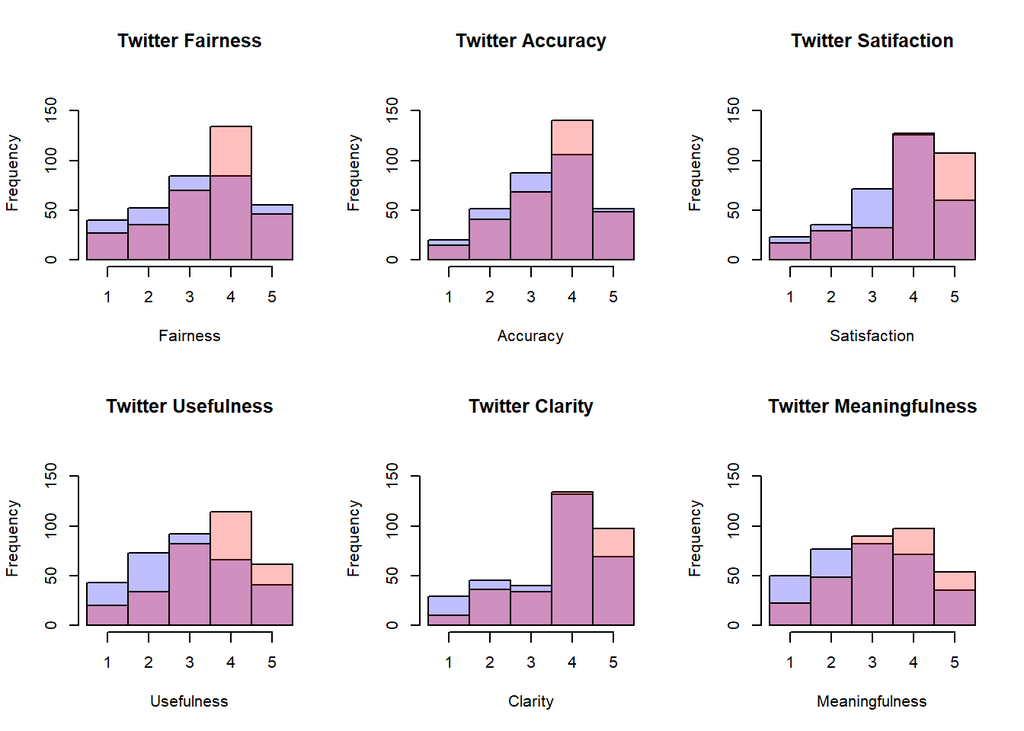

```r
par(mfrow=c(2,3))
hist(dt$tcFair, col=rgb(0,0,1,1/4), breaks = seq(0.5, 5.5, 1),
     main= "Twitter Fairness", xlab="Fairness", ylim=c(0,175))
hist(dt$ttFair,col=rgb(1,0,0,1/4), breaks = seq(0.5, 5.5, 1), add=T)
#legend("topright", c("Control", "Treatment"), fill=c("blue", "red"))

hist(dt$tcAcc, col=rgb(0,0,1,1/4), breaks = seq(0.5, 5.5, 1),
     main= "Twitter Accuracy", xlab="Accuracy", ylim=c(0,175))
hist(dt$ttAcc,col=rgb(1,0,0,1/4), breaks = seq(0.5, 5.5, 1), add=T)

hist(dt$tcSat, col=rgb(0,0,1,1/4), breaks = seq(0.5, 5.5, 1),
     main= "Twitter Satifaction", xlab="Satisfaction", ylim=c(0,175))
hist(dt$ttSat,col=rgb(1,0,0,1/4), breaks = seq(0.5, 5.5, 1), add=T)

hist(dt$tcUseful, col=rgb(0,0,1,1/4), breaks = seq(0.5, 5.5, 1),
     main= "Twitter Usefulness", xlab="Usefulness", ylim=c(0,175))
hist(dt$ttUseful,col=rgb(1,0,0,1/4), breaks = seq(0.5, 5.5, 1), add=T)

hist(dt$tcClear, col=rgb(0,0,1,1/4), breaks = seq(0.5, 5.5, 1),
     main= "Twitter Clarity", xlab="Clarity", ylim=c(0,175))
hist(dt$ttClear,col=rgb(1,0,0,1/4), breaks = seq(0.5, 5.5, 1), add=T)

hist(dt$tcMeaningful, col=rgb(0,0,1,1/4), breaks = seq(0.5, 5.5, 1),
     main= "Twitter Meaningfulness", xlab="Meaningfulness", ylim=c(0,175))
hist(dt$ttMeaningful,col=rgb(1,0,0,1/4), breaks = seq(0.5, 5.5, 1), add=T)
```

### Recidivism Responses Histogram

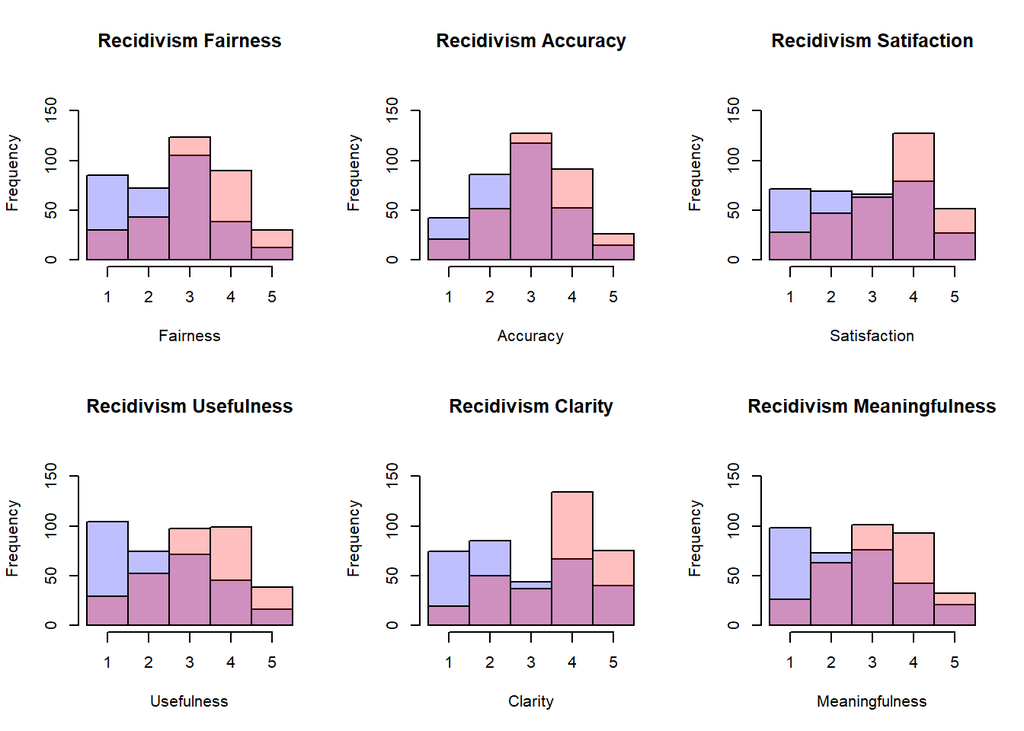

```r
par(mfrow=c(2,3))
hist(dt$rcFair, col=rgb(0,0,1,1/4), breaks = seq(0.5, 5.5, 1), main= "Recidivism Fairness", xlab="Fairness", ylim=c(0,175))
hist(dt$rtFair,col=rgb(1,0,0,1/4), breaks = seq(0.5, 5.5, 1), add=T)
#legend("topright", c("Control", "Treatment"), fill=c("blue", "red"))

hist(dt$rcAcc, col=rgb(0,0,1,1/4), breaks = seq(0.5, 5.5, 1), main= "Recidivism Accuracy", xlab="Accuracy", ylim=c(0,175))
hist(dt$rtAcc,col=rgb(1,0,0,1/4), breaks = seq(0.5, 5.5, 1), add=T)

hist(dt$rcSat, col=rgb(0,0,1,1/4), breaks = seq(0.5, 5.5, 1), main= "Recidivism Satifaction", xlab="Satisfaction", ylim=c(0,175))
hist(dt$rtSat,col=rgb(1,0,0,1/4), breaks = seq(0.5, 5.5, 1), add=T)

hist(dt$rcUseful, col=rgb(0,0,1,1/4), breaks = seq(0.5, 5.5, 1), main= "Recidivism Usefulness", xlab="Usefulness", ylim=c(0,175))
hist(dt$rtUseful,col=rgb(1,0,0,1/4), breaks = seq(0.5, 5.5, 1), add=T)

hist(dt$rcClear, col=rgb(0,0,1,1/4), breaks = seq(0.5, 5.5, 1), main= "Recidivism Clarity", xlab="Clarity", ylim=c(0,175))
hist(dt$rtClear,col=rgb(1,0,0,1/4), breaks = seq(0.5, 5.5, 1), add=T)

hist(dt$rcMeaningful, col=rgb(0,0,1,1/4), breaks = seq(0.5, 5.5, 1), main= "Recidivism Meaningfulness", xlab="Meaningfulness", ylim=c(0,175))
hist(dt$rtMeaningful,col=rgb(1,0,0,1/4), breaks = seq(0.5, 5.5, 1), add=T)
```

### Twitter Histograms Greyscale

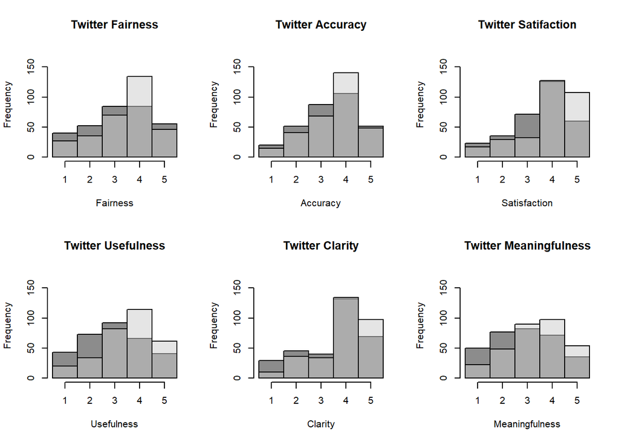

```r
par(mfrow=c(2,3))
hist(dt$tcFair, col=rgb(0.1,0.1,0.1,0.5), breaks = seq(0.5, 5.5, 1), main= "Twitter Fairness", xlab="Fairness", ylim=c(0,175))
hist(dt$ttFair,col=rgb(0.8,0.8,0.8,0.5), breaks = seq(0.5, 5.5, 1), add=T)
#legend("topright", c("Control", "Treatment"), fill=c("blue", "red"))

hist(dt$tcAcc, col=rgb(0.1,0.1,0.1,0.5), breaks = seq(0.5, 5.5, 1), main= "Twitter Accuracy", xlab="Accuracy", ylim=c(0,175))
hist(dt$ttAcc,col=rgb(0.8,0.8,0.8,0.5), breaks = seq(0.5, 5.5, 1), add=T)

hist(dt$tcSat, col=rgb(0.1,0.1,0.1,0.5), breaks = seq(0.5, 5.5, 1), main= "Twitter Satifaction", xlab="Satisfaction", ylim=c(0,175))
hist(dt$ttSat,col=rgb(0.8,0.8,0.8,0.5), breaks = seq(0.5, 5.5, 1), add=T)

hist(dt$tcUseful, col=rgb(0.1,0.1,0.1,0.5), breaks = seq(0.5, 5.5, 1), main= "Twitter Usefulness", xlab="Usefulness", ylim=c(0,175))
hist(dt$ttUseful,col=rgb(0.8,0.8,0.8,0.5), breaks = seq(0.5, 5.5, 1), add=T)

hist(dt$tcClear, col=rgb(0.1,0.1,0.1,0.5), breaks = seq(0.5, 5.5, 1), main= "Twitter Clarity", xlab="Clarity", ylim=c(0,175))
hist(dt$ttClear,col=rgb(0.8,0.8,0.8,0.5), breaks = seq(0.5, 5.5, 1), add=T)

hist(dt$tcMeaningful, col=rgb(0.1,0.1,0.1,0.5), breaks = seq(0.5, 5.5, 1), main= "Twitter Meaningfulness", xlab="Meaningfulness", ylim=c(0,175))
hist(dt$ttMeaningful,col=rgb(0.8,0.8,0.8,0.5), breaks = seq(0.5, 5.5, 1), add=T)
```

### Recidivism Histogram Greyscale

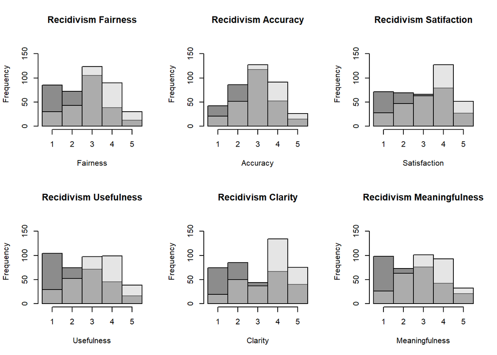

```r
par(mfrow=c(2,3))
hist(dt$rcFair, col=rgb(0.1,0.1,0.1,0.5), breaks = seq(0.5, 5.5, 1), main= "Recidivism Fairness", xlab="Fairness", ylim=c(0,175))
hist(dt$rtFair,col=rgb(0.8,0.8,0.8,0.5), breaks = seq(0.5, 5.5, 1), add=T)
#legend("topright", c("Control", "Treatment"), fill=c("blue", "red"))

hist(dt$rcAcc, col=rgb(0.1,0.1,0.1,0.5), breaks = seq(0.5, 5.5, 1), main= "Recidivism Accuracy", xlab="Accuracy", ylim=c(0,175))
hist(dt$rtAcc,col=rgb(0.8,0.8,0.8,0.5), breaks = seq(0.5, 5.5, 1), add=T)

hist(dt$rcSat, col=rgb(0.1,0.1,0.1,0.5), breaks = seq(0.5, 5.5, 1), main= "Recidivism Satifaction", xlab="Satisfaction", ylim=c(0,175))
#legend(4,9, Treat(df),lwd=4, col=c())
hist(dt$rtSat,col=rgb(0.8,0.8,0.8,0.5), breaks = seq(0.5, 5.5, 1), add=T)

hist(dt$rcUseful, col=rgb(0.1,0.1,0.1,0.5), breaks = seq(0.5, 5.5, 1), main= "Recidivism Usefulness", xlab="Usefulness", ylim=c(0,175))
hist(dt$rtUseful,col=rgb(0.8,0.8,0.8,0.5), breaks = seq(0.5, 5.5, 1), add=T)

hist(dt$rcClear, col=rgb(0.1,0.1,0.1,0.5), breaks = seq(0.5, 5.5, 1), main= "Recidivism Clarity", xlab="Clarity", ylim=c(0,175))
hist(dt$rtClear,col=rgb(0.8,0.8,0.8,0.5), breaks = seq(0.5, 5.5, 1), add=T)

hist(dt$rcMeaningful, col=rgb(0.1,0.1,0.1,0.5), breaks = seq(0.5, 5.5, 1), main= "Recidivism Meaningfulness", xlab="Meaningfulness", ylim=c(0,175))
hist(dt$rtMeaningful,col=rgb(0.8,0.8,0.8,0.5), breaks = seq(0.5, 5.5, 1), add=T)
```

### Demographic

```r
#ageGroup','race','gender','socMed','educ','feedback','duration'

# par(mfrow=c(2,2))
# hist(dt$gender,breaks=3, main = "Gender")
# hist(dt$socMed,breaks=5, main= "Social Media Usage")
# hist(dt$edu,breaks=5, main = "Educational level")
# hist(dt$duration,breaks=3, main = "Duration")
```

## Regression Models

### Twitter Moderation

Create linear models for each question for both Twitter and recidivism. The models subset the data to look only at those respondents that were assigned to either treatment or control for that context. In this way, someone who attrited in teh first context will not count against the second context.

```r
mtFair <- ivreg(tFair ~ tTreat, data = dc[tAssign == 1])
mtAcc <- ivreg(tAcc ~ tTreat, data = dc[tAssign == 1])
mtSat <- ivreg(tSat ~ tTreat, data = dc[tAssign == 1])
mtUseful <- ivreg(tUseful ~ tTreat, data = dc[tAssign == 1])
mtClear <- ivreg(tClear ~ tTreat, data = dc[tAssign == 1])
mtMeaningful <- ivreg(tMeaningful ~ tTreat, data = dc[tAssign == 1])

stargazer(mtFair, mtAcc, mtSat, mtUseful, mtClear, mtMeaningful,
          type = 'text',
          covariate.labels = c("Explanation"),
          dep.var.labels = c("Fairness", "Accuracy", "Satisfaction", "Usefulness",
                             "Clarity", "Meaningfulness"),
          dep.var.caption = "Twitter Moderation")
```

```
##
## ================================================================================================
##                                                       Twitter Moderation
##                                -----------------------------------------------------------------
##                                Fairness Accuracy Satisfaction Usefulness Clarity  Meaningfulness
##                                  (1)      (2)        (3)         (4)       (5)         (6)
## ------------------------------------------------------------------------------------------------
## Explanation                    0.242**   0.157*    0.367***    0.545***  0.332***    0.467***
##                                (0.096)  (0.087)    (0.091)     (0.094)   (0.093)     (0.096)
##
## Constant                       3.197*** 3.371***   3.524***    2.965***  3.530***    2.886***
##                                (0.068)  (0.061)    (0.064)     (0.067)   (0.066)     (0.068)
##
## ------------------------------------------------------------------------------------------------
## Observations                     627      627        627         627       627         627
## R2                              0.010    0.005      0.025       0.050     0.020       0.036
## Adjusted R2                     0.008    0.004      0.024       0.049     0.018       0.035
## Residual Std. Error (df = 625)  1.203    1.091      1.139       1.183     1.170       1.202
## ================================================================================================
## Note:                                                                *p<0.1; **p<0.05; ***p<0.01
```

```r
dc[(tAssign == 1 & tSat == 0), .N]
```

```
## [1] 0
```

```r
dc[(tAssign == 1 & tMeaningful == 0), .N]
```

```
## [1] 1
```

This shows that 1 person dropped out between seeing the treatment and responding in the Twitter context. This is probably not affecting our last few metrics, but they are all statistically significant by a large margin anyway. This represents our intent to treat effect.

However, they get through all of the first three questions, so those responses are not affected by attrition.

```r
mrFair <- lm(rFair ~ rTreat, data = dc[rAssign == 1])
mrAcc <- lm(rAcc ~ rTreat, data = dc[rAssign == 1])
mrSat <- lm(rSat ~ rTreat, data = dc[rAssign == 1])
mrUseful <- lm(rUseful ~ rTreat, data = dc[rAssign == 1])
mrClear <- lm(rClear ~ rTreat, data = dc[rAssign == 1])
mrMeaningful <- lm(rMeaningful ~ rTreat, data = dc[rAssign == 1])

stargazer(mrFair, mrAcc, mrSat, mrUseful, mrClear, mrMeaningful,
          type = 'text',
          covariate.labels = c("Explanation"),
          dep.var.labels = c("Fairness", "Accuracy", "Satisfaction", "Usefulness",
                             "Clarity", "Meaningfulness"),
          dep.var.caption = "Recidivism Risk Assessment")
```

```
##
## ===================================================================================================
##                                                     Recidivism Risk Assessment
##                                --------------------------------------------------------------------
##                                Fairness  Accuracy  Satisfaction Usefulness  Clarity  Meaningfulness
##                                   (1)       (2)        (3)         (4)        (5)         (6)
## ---------------------------------------------------------------------------------------------------
## Explanation                    0.726***  0.440***    0.649***    0.872***  0.906***     0.736***
##                                 (0.088)   (0.082)    (0.099)     (0.095)    (0.103)     (0.095)
##
## Constant                       2.423***  2.718***    2.750***    2.324***  2.705***     2.388***
##                                 (0.062)   (0.058)    (0.070)     (0.068)    (0.073)     (0.067)
##
## ---------------------------------------------------------------------------------------------------
## Observations                      628       628        628         628        628         628
## R2                               0.098     0.044      0.064       0.118      0.109       0.088
## Adjusted R2                      0.097     0.042      0.063       0.117      0.108       0.086
## Residual Std. Error (df = 626)   1.102     1.029      1.239       1.192      1.295       1.189
## F Statistic (df = 1; 626)      68.079*** 28.723***  43.073***   84.045***  76.767***   60.139***
## ===================================================================================================
## Note:                                                                   *p<0.1; **p<0.05; ***p<0.01
```

```r
dc[(rAssign == 1 & rSat == 0), .N]
```

```
## [1] 0
```

```r
dc[(rAssign == 1 & rMeaningful == 0), .N]
```

```
## [1] 3
```

This shows that 3 people dropped out between seeing the treatment and responding in the recidivism context. This could be throwing off the last few metrics, but those are all statistically significant by a large margin. This represents our intent to treat effect.

## Difference in Order

We also discussed looking at the difference in responses depending on the order of contexts.

```r
otFair <-       lm(tFair ~ First.Context + tTreat + rTreat + tTreat*rTreat, data = dc[tAssign == 1])
otAcc <-        lm(tAcc ~ First.Context+ tTreat + rTreat + tTreat*rTreat, data = dc[tAssign == 1])
otSat <-        lm(tSat ~ First.Context+ tTreat + rTreat + tTreat*rTreat, data = dc[tAssign == 1])
otUseful <-     lm(tUseful ~ First.Context+ tTreat + rTreat + tTreat*rTreat, data = dc[tAssign == 1])
otClear <-      lm(tClear ~ First.Context+ tTreat + rTreat + tTreat*rTreat, data = dc[tAssign == 1])
otMeaningful <- lm(tMeaningful ~ First.Context+ tTreat + rTreat + tTreat*rTreat, data = dc[tAssign == 1])

library(stargazer)
stargazer(otFair, otAcc, otSat, otUseful, otClear, otMeaningful,
          type = 'text',
          dep.var.labels = c("Fairness", "Accuracy", "Satisfaction", "Usefulness",
                             "Clarity", "Meaningfulness"),
          dep.var.caption = "Twitter Moderation")
```

```
##
## ================================================================================================
##                                                       Twitter Moderation
##                                -----------------------------------------------------------------
##                                Fairness Accuracy Satisfaction Usefulness Clarity  Meaningfulness
##                                  (1)      (2)        (3)         (4)       (5)         (6)
## ------------------------------------------------------------------------------------------------
## First.ContextTwitter            0.102    0.153*     0.160*      0.012     0.018       -0.112
##                                (0.096)  (0.087)    (0.091)     (0.095)   (0.094)     (0.096)
##
## tTreat                         0.268**   0.224*    0.517***    0.656***  0.448***    0.629***
##                                (0.136)  (0.123)    (0.128)     (0.134)   (0.132)     (0.136)
##
## rTreat                          -0.050   0.110      0.123       0.108     0.124       0.254*
##                                (0.136)  (0.123)    (0.128)     (0.133)   (0.132)     (0.135)
##
## tTreat:rTreat                   -0.050   -0.133     -0.298      -0.223    -0.231     -0.324*
##                                (0.192)  (0.174)    (0.182)     (0.189)   (0.187)     (0.192)
##
## Constant                       3.170*** 3.239***   3.381***    2.905***  3.459***    2.816***
##                                (0.107)  (0.097)    (0.101)     (0.106)   (0.105)     (0.107)
##
## ------------------------------------------------------------------------------------------------
## Observations                     627      627        627         627       627         627
## R2                              0.013    0.011      0.035       0.053     0.022       0.044
## Adjusted R2                     0.007    0.005      0.028       0.047     0.016       0.038
## Residual Std. Error (df = 622)  1.204    1.090      1.136       1.184     1.171       1.200
## F Statistic (df = 4; 622)       2.040*   1.801     5.585***    8.635***  3.541***    7.214***
## ================================================================================================
## Note:                                                                *p<0.1; **p<0.05; ***p<0.01
```

In the case of Twitter moderation, there does not seem to be a difference based on order of context.

```r
orFair <-       lm(rFair ~ First.Context + rTreat + tTreat + rTreat*tTreat, data = dc[rAssign == 1])
orAcc <-        lm(rAcc ~ First.Context + rTreat + tTreat + rTreat*tTreat, data = dc[rAssign == 1])
orSat <-        lm(rSat ~ First.Context + rTreat + tTreat + rTreat*tTreat, data = dc[rAssign == 1])
orUseful <-     lm(rUseful ~ First.Context + rTreat + tTreat + rTreat*tTreat, data = dc[rAssign == 1])
orClear <-      lm(rClear ~ First.Context + rTreat + tTreat + rTreat*tTreat, data = dc[rAssign == 1])
orMeaningful <- lm(rMeaningful ~ First.Context + rTreat + tTreat + rTreat*tTreat, data = dc[rAssign == 1])

library(stargazer)
stargazer(orFair, orAcc, orSat, orUseful, orClear, orMeaningful,
          type = 'text',
          dep.var.labels = c("Fairness", "Accuracy", "Satisfaction", "Usefulness",
                             "Clarity", "Meaningfulness"),
          dep.var.caption = "Recidivism Risk Assessment")
```

```
##
## ==================================================================================================
##                                                    Recidivism Risk Assessment
##                                -------------------------------------------------------------------
##                                Fairness  Accuracy Satisfaction Usefulness  Clarity  Meaningfulness
##                                   (1)      (2)        (3)         (4)        (5)         (6)
## --------------------------------------------------------------------------------------------------
## First.ContextTwitter            -0.063    -0.043     -0.140     -0.191**  -0.263**      -0.110
##                                 (0.088)  (0.082)    (0.099)     (0.095)    (0.103)     (0.095)
##
## rTreat                         0.608***  0.430***   0.658***    0.862***  0.885***     0.716***
##                                 (0.124)  (0.116)    (0.139)     (0.134)    (0.145)     (0.134)
##
## tTreat                           0.012    0.019      0.201       0.159      0.100       -0.020
##                                 (0.125)  (0.117)    (0.140)     (0.135)    (0.146)     (0.135)
##
## rTreat:tTreat                    0.236    0.020      -0.020      0.019      0.039       0.040
##                                 (0.176)  (0.165)    (0.197)     (0.190)    (0.206)     (0.190)
##
## Constant                       2.449***  2.730***   2.721***    2.341***  2.788***     2.453***
##                                 (0.098)  (0.092)    (0.110)     (0.106)    (0.115)     (0.106)
##
## --------------------------------------------------------------------------------------------------
## Observations                      628      628        628         628        628         628
## R2                               0.105    0.045      0.073       0.128      0.120       0.090
## Adjusted R2                      0.099    0.038      0.067       0.123      0.115       0.084
## Residual Std. Error (df = 623)   1.101    1.031      1.236       1.188      1.290       1.190
## F Statistic (df = 4; 623)      18.199*** 7.255***  12.252***   22.951***  21.312***   15.347***
## ==================================================================================================
## Note:                                                                  *p<0.1; **p<0.05; ***p<0.01
```

## Other Factors

```r
otFair <-       lm(tFair ~ tTreat + ageGroup + educ + socMed + black + asian + hispanic + other + pac_isle + female + gender_nc, data = dc)
otAcc <-        lm(tAcc ~ tTreat + ageGroup + educ + socMed + black + asian + hispanic + other + pac_isle + female + gender_nc, data = dc)
otSat <-        lm(tSat ~ tTreat + ageGroup + educ + socMed + black + asian + hispanic + other + pac_isle + female + gender_nc, data = dc)
otUseful <-     lm(tUseful ~ tTreat + ageGroup + educ + socMed + black + asian + hispanic + other + pac_isle + female + gender_nc, data = dc)
otClear <-      lm(tClear ~ tTreat + ageGroup + educ + socMed + black + asian + hispanic + other + pac_isle + female + gender_nc, data = dc)
otMeaningful <- lm(tMeaningful ~ tTreat + ageGroup + educ + socMed + black + asian + hispanic + other + pac_isle + female + gender_nc, data = dc)

library(stargazer)
stargazer(otFair, otAcc, otSat, otUseful, otClear, otMeaningful,
          type = 'text',
          covariate.labels = c("Explanation", "Age Group", "Education", "Social Media"),
          dep.var.labels = c("Fairness", "Accuracy", "Satisfaction", "Usefulness",
                             "Clarity", "Meaningfulness"),
          dep.var.caption = "Twitter Moderation")
```

```
##
## =================================================================================================
##                                                        Twitter Moderation
##                                ------------------------------------------------------------------
##                                Fairness  Accuracy Satisfaction Usefulness Clarity  Meaningfulness
##                                   (1)      (2)        (3)         (4)       (5)         (6)
## -------------------------------------------------------------------------------------------------
## Explanation                     0.219**   0.148*    0.347***    0.555***  0.350***    0.489***
##                                 (0.096)  (0.088)    (0.092)     (0.094)   (0.093)     (0.096)
##
## Age Group                        0.016    0.036      0.008       -0.025    0.004       0.025
##                                 (0.043)  (0.039)    (0.041)     (0.042)   (0.042)     (0.043)
##
## Education                        0.031    0.004      0.022       0.037     0.004       0.026
##                                 (0.037)  (0.034)    (0.036)     (0.037)   (0.036)     (0.037)
##
## Social Media                     0.022    0.041     -0.097*      -0.077   -0.142**    -0.102*
##                                 (0.062)  (0.056)    (0.059)     (0.061)   (0.060)     (0.061)
##
## black                           -0.203    -0.174     -0.116      -0.236    -0.328      -0.182
##                                 (0.207)  (0.188)    (0.197)     (0.203)   (0.200)     (0.205)
##
## asian                           -0.130    -0.031     0.054       0.078     0.057       0.227*
##                                 (0.127)  (0.115)    (0.121)     (0.124)   (0.123)     (0.126)
##
## hispanic                        -0.429*   -0.252     -0.135     -0.406*    -0.157     -0.548**
##                                 (0.230)  (0.209)    (0.219)     (0.226)   (0.223)     (0.228)
##
## other                          -1.579***  -0.680     -0.459      -0.208    -0.464      -0.637
##                                 (0.538)  (0.489)    (0.513)     (0.528)   (0.520)     (0.534)
##
## pac_isle                         0.714    0.591      1.093      -2.649**  -1.945*     -2.630**
##                                 (1.199)  (1.090)    (1.143)     (1.175)   (1.159)     (1.189)
##
## female                         0.265***  0.269***   0.224**      0.117     0.188*      0.025
##                                 (0.102)  (0.093)    (0.097)     (0.100)   (0.099)     (0.101)
##
## gender_nc                        0.600    0.596      0.154       0.405     0.117       -0.378
##                                 (1.199)  (1.090)    (1.143)     (1.175)   (1.159)     (1.189)
##
## Constant                       2.666***  3.088***   3.250***    2.613***  3.602***    2.552***
##                                 (0.539)  (0.490)    (0.514)     (0.528)   (0.521)     (0.535)
##
## -------------------------------------------------------------------------------------------------
## Observations                      620      620        620         620       620         620
## R2                               0.044    0.030      0.042       0.077     0.048       0.073
## Adjusted R2                      0.027    0.012      0.025       0.060     0.031       0.056
## Residual Std. Error (df = 608)   1.193    1.085      1.137       1.170     1.154       1.183
## F Statistic (df = 11; 608)     2.549***   1.699*    2.442***    4.603***  2.780***    4.347***
## =================================================================================================
## Note:                                                                 *p<0.1; **p<0.05; ***p<0.01
```

Women were statistically significantly more likely than men to agree with the Twitter decision. Pacific Islanders did not like the explanation.

```r
orFair <-       lm(rFair ~ rTreat + ageGroup + educ + socMed + black + asian + hispanic + other + pac_isle + female + gender_nc, data = dc)
orAcc <-        lm(rAcc ~ rTreat + ageGroup + educ + socMed + black + asian + hispanic + other + pac_isle + female + gender_nc, data = dc)
orSat <-        lm(rSat ~ rTreat + ageGroup + educ + socMed + black + asian + hispanic + other + pac_isle + female + gender_nc, data = dc)
orUseful <-     lm(rUseful ~ rTreat + ageGroup + educ + socMed + black + asian + hispanic + other + pac_isle + female + gender_nc, data = dc)
orClear <-      lm(rClear ~ rTreat + ageGroup + educ + socMed + black + asian + hispanic + other + pac_isle + female + gender_nc, data = dc)
orMeaningful <- lm(rMeaningful ~ rTreat + ageGroup + educ + socMed + black + asian + hispanic + other + pac_isle + female + gender_nc, data = dc)

library(stargazer)
stargazer(otFair, otAcc, otSat, otUseful, otClear, otMeaningful,
          type = 'text',
          covariate.labels = c("Explanation", "Age Group", "Education", "Social Media"),
          dep.var.labels = c("Fairness", "Accuracy", "Satisfaction", "Usefulness",
                             "Clarity", "Meaningfulness"),
          dep.var.caption = "Recidivism Risk Assessment")
```

```
##
## =================================================================================================
##                                                    Recidivism Risk Assessment
##                                ------------------------------------------------------------------
##                                Fairness  Accuracy Satisfaction Usefulness Clarity  Meaningfulness
##                                   (1)      (2)        (3)         (4)       (5)         (6)
## -------------------------------------------------------------------------------------------------
## Explanation                     0.219**   0.148*    0.347***    0.555***  0.350***    0.489***
##                                 (0.096)  (0.088)    (0.092)     (0.094)   (0.093)     (0.096)
##
## Age Group                        0.016    0.036      0.008       -0.025    0.004       0.025
##                                 (0.043)  (0.039)    (0.041)     (0.042)   (0.042)     (0.043)
##
## Education                        0.031    0.004      0.022       0.037     0.004       0.026
##                                 (0.037)  (0.034)    (0.036)     (0.037)   (0.036)     (0.037)
##
## Social Media                     0.022    0.041     -0.097*      -0.077   -0.142**    -0.102*
##                                 (0.062)  (0.056)    (0.059)     (0.061)   (0.060)     (0.061)
##
## black                           -0.203    -0.174     -0.116      -0.236    -0.328      -0.182
##                                 (0.207)  (0.188)    (0.197)     (0.203)   (0.200)     (0.205)
##
## asian                           -0.130    -0.031     0.054       0.078     0.057       0.227*
##                                 (0.127)  (0.115)    (0.121)     (0.124)   (0.123)     (0.126)
##
## hispanic                        -0.429*   -0.252     -0.135     -0.406*    -0.157     -0.548**
##                                 (0.230)  (0.209)    (0.219)     (0.226)   (0.223)     (0.228)
##
## other                          -1.579***  -0.680     -0.459      -0.208    -0.464      -0.637
##                                 (0.538)  (0.489)    (0.513)     (0.528)   (0.520)     (0.534)
##
## pac_isle                         0.714    0.591      1.093      -2.649**  -1.945*     -2.630**
##                                 (1.199)  (1.090)    (1.143)     (1.175)   (1.159)     (1.189)
##
## female                         0.265***  0.269***   0.224**      0.117     0.188*      0.025
##                                 (0.102)  (0.093)    (0.097)     (0.100)   (0.099)     (0.101)
##
## gender_nc                        0.600    0.596      0.154       0.405     0.117       -0.378
##                                 (1.199)  (1.090)    (1.143)     (1.175)   (1.159)     (1.189)
##
## Constant                       2.666***  3.088***   3.250***    2.613***  3.602***    2.552***
##                                 (0.539)  (0.490)    (0.514)     (0.528)   (0.521)     (0.535)
##
## -------------------------------------------------------------------------------------------------
## Observations                      620      620        620         620       620         620
## R2                               0.044    0.030      0.042       0.077     0.048       0.073
## Adjusted R2                      0.027    0.012      0.025       0.060     0.031       0.056
## Residual Std. Error (df = 608)   1.193    1.085      1.137       1.170     1.154       1.183
## F Statistic (df = 11; 608)     2.549***   1.699*    2.442***    4.603***  2.780***    4.347***
## =================================================================================================
## Note:                                                                 *p<0.1; **p<0.05; ***p<0.01
```

Again, Pacific Islanders rated the explanation worse than others.

## Data Checks

```r
d[is.na(random)]
```

[output not shown]

[output cut: 225 more lines]